# Data Science Sentimental Text Lab

## Article: Small islands caught between tourism economy, climate change

Newspaper: The Associated Press

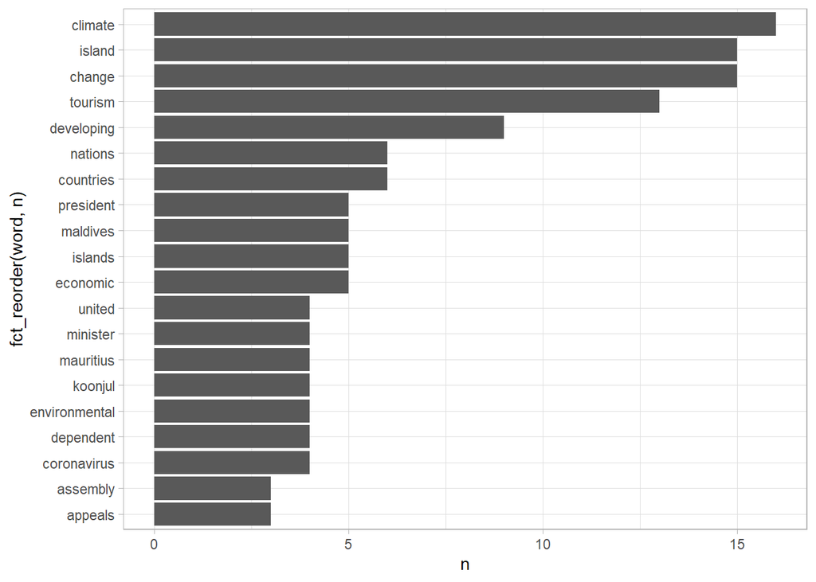

```r
NEarticle11 <- read_lines("07_text_mining/Small islands.txt")

NEarticle11 <- tibble(NEarticle11)
#View(NEarticle11)

NEarticle11$NEarticle11 <- as.character(NEarticle11$NEarticle11)

NEarticle11 <- NEarticle11 %>%
  unnest_tokens(word, NEarticle11)%>%
  anti_join(stop_words)%>%
  count(word, sort=TRUE)
#View(NEarticle11)

ggplot(
  data = NEarticle11[1:20,],
  aes(x = fct_reorder(word,n),
      y = n)
  ) +
  geom_col() +
  coord_flip()+
  theme_light()
```

```r
#evaluating words for their connotation
NEarticle11_affin <- NEarticle11 %>%
  inner_join(get_sentiments("afinn"))#using a inner join to match words and add the sentiment variable
NEarticle11_nrc <- NEarticle11 %>%
  inner_join(get_sentiments("nrc"))
NEarticle11_bing <- NEarticle11 %>%
  inner_join(get_sentiments("bing"))
#We can just do some tabling to see the differences in bing and nrc, seems like Kennedy's speech at least first glanced was much more balanced in terms of negative/positive sentiment
table(NEarticle11_bing$sentiment) #much more positive
```

```
##
## negative positive
##       33       17
```

```r
table(NEarticle11_nrc$sentiment)
```

```
##
##        anger anticipation      disgust         fear          joy     negative
##           11           21            8           18            9           28
##     positive      sadness     surprise        trust
##           53           14            9           30
```

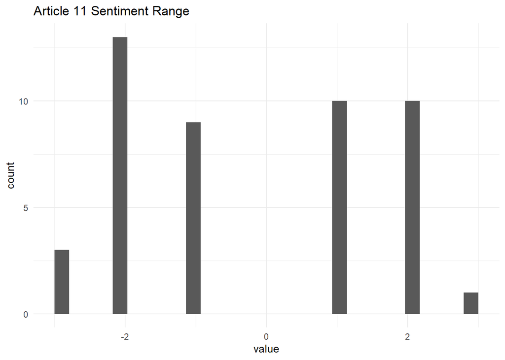

```r
#View(NEarticle11_affin)

ggplot(data = NEarticle11_affin,
       aes(x=value)
        )+
  geom_histogram()+
  ggtitle("Article 11 Sentiment Range")+
  theme_minimal()
```

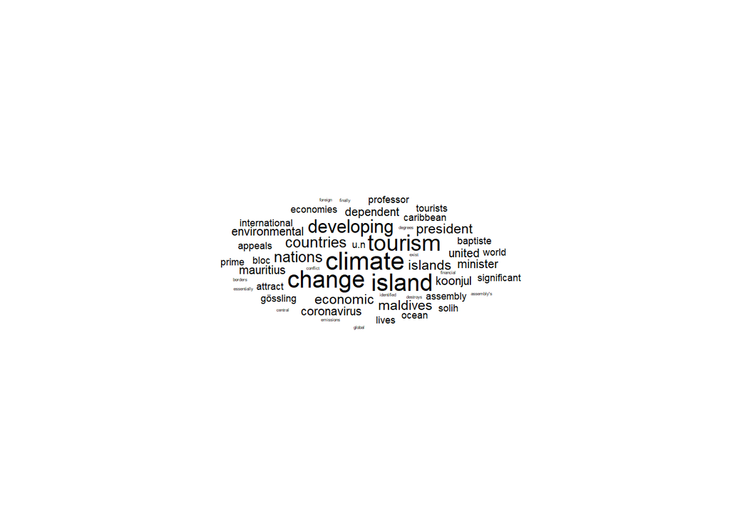

```r
#Could also do simple word clouds as we see
#below uses the ggwordcloud package

set.seed(42)
ggplot(NEarticle11[1:50,], aes(label = word, size = n)
       ) +
  geom_text_wordcloud() +
  theme_minimal()
```

## Article: The Latest: EPA chief mum on Trump’s beliefs on climate

Newspaper: The Associated Press

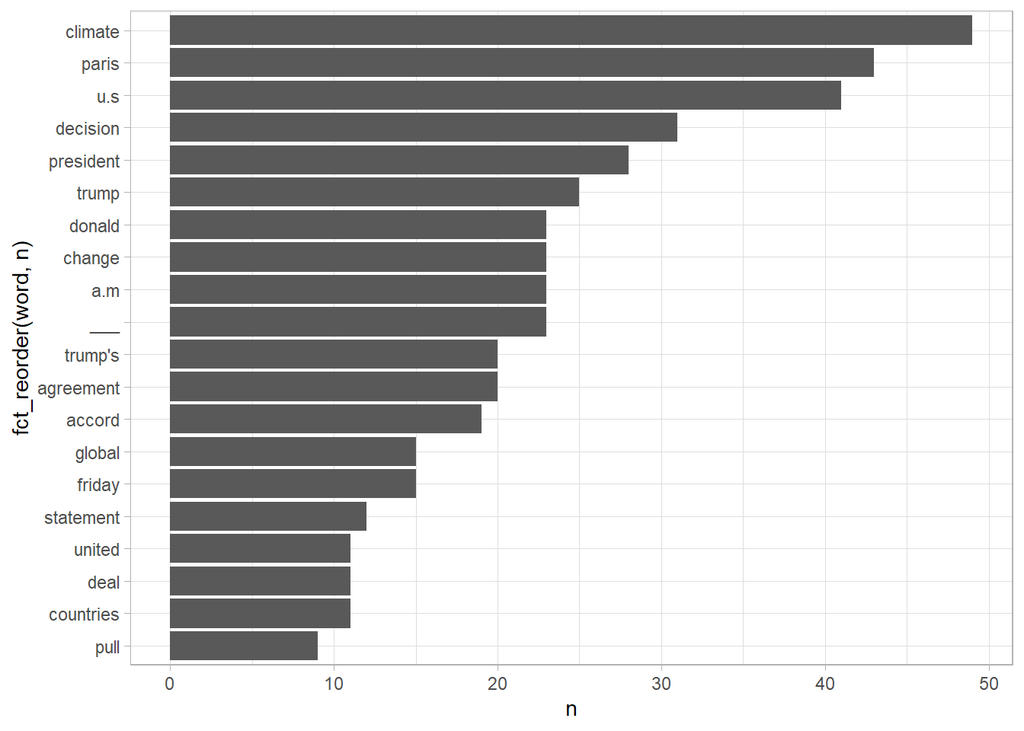

```r
NEarticle12 <- read_lines("07_text_mining/The Latest_ EPA.txt")

NEarticle12 <- tibble(NEarticle12)
#View(NEarticle12)

NEarticle12$NEarticle12 <- as.character(NEarticle12$NEarticle12)

NEarticle12 <- NEarticle12 %>%
  unnest_tokens(word, NEarticle12)%>%
  anti_join(stop_words)%>%
  count(word, sort=TRUE)
#View(NEarticle12)

ggplot(
  data = NEarticle12[1:20,],
  aes(x = fct_reorder(word,n),
      y = n)
  ) +
  geom_col() +
  coord_flip()+
  theme_light()
```

```r
#evaluating words for their connotation
NEarticle12_affin <- NEarticle12 %>%
  inner_join(get_sentiments("afinn"))#using a inner join to match words and add the sentiment variable
NEarticle12_nrc <- NEarticle12 %>%
  inner_join(get_sentiments("nrc"))
NEarticle12_bing <- NEarticle12 %>%
  inner_join(get_sentiments("bing"))
#We can just do some tabling to see the differences in bing and nrc, seems like Kennedy's speech at least first glanced was much more balanced in terms of negative/positive sentiment
table(NEarticle12_bing$sentiment) #much more positive
```

```
##
## negative positive
##       57       33
```

```r
table(NEarticle12_nrc$sentiment)
```

```
##
##        anger anticipation      disgust         fear          joy     negative
##           21           30           11           25           26           50
##     positive      sadness     surprise        trust
##           92           21           11           59
```

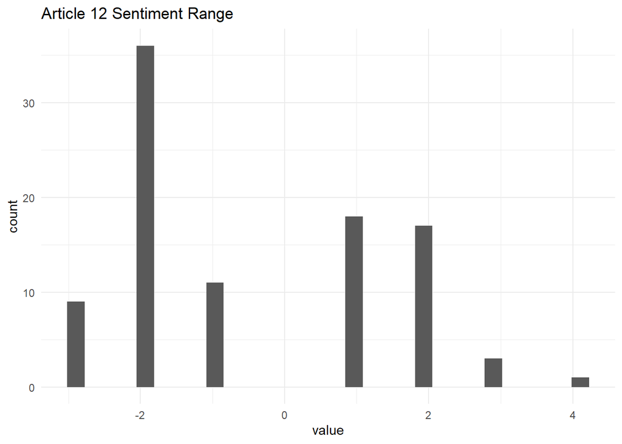

```r
#View(NEarticle12_affin)

ggplot(data = NEarticle12_affin,
       aes(x=value)
        )+
  geom_histogram()+
  ggtitle("Article 12 Sentiment Range")+
  theme_minimal()
```

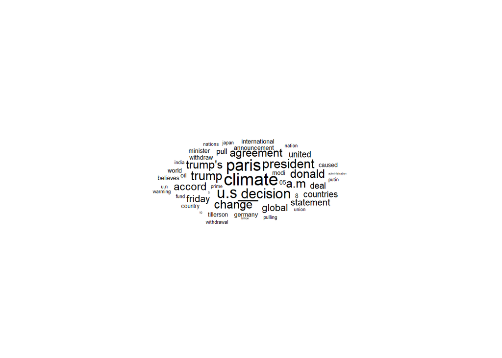

```r
#Could also do simple word clouds as we see
#below uses the ggwordcloud package

set.seed(42)
ggplot(NEarticle12[1:50,], aes(label = word, size = n)
       ) +
  geom_text_wordcloud() +
  theme_minimal()
```

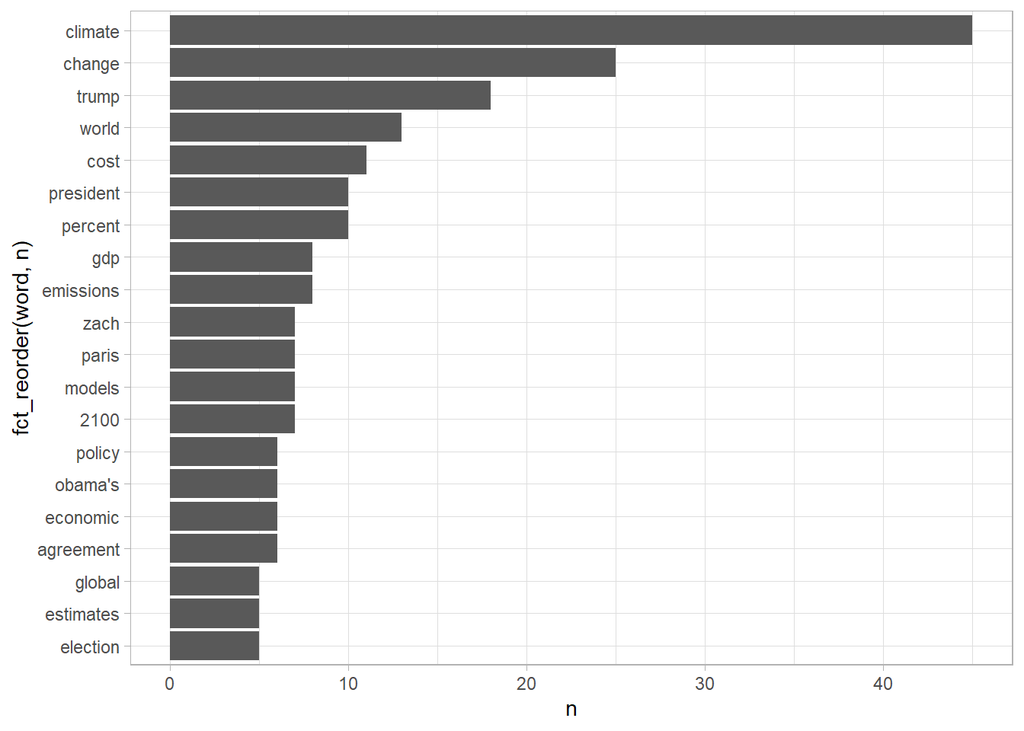

```r
NEarticle13 <- read_lines("07_text_mining/Trump the Climate-Slayer.txt")

NEarticle13 <- tibble(NEarticle13)
#View(NEarticle13)

NEarticle13$NEarticle13 <- as.character(NEarticle13$NEarticle13)

NEarticle13 <- NEarticle13 %>%
  unnest_tokens(word, NEarticle13)%>%
  anti_join(stop_words)%>%
  count(word, sort=TRUE)
#View(NEarticle13)

ggplot(
  data = NEarticle13[1:20,],
  aes(x = fct_reorder(word,n),
      y = n)
  ) +
  geom_col() +
  coord_flip()+
  theme_light()
```

```r
#evaluating words for their connotation
NEarticle13_affin <- NEarticle13 %>%
  inner_join(get_sentiments("afinn"))#using a inner join to match words and add the sentiment variable
NEarticle13_nrc <- NEarticle13 %>%
  inner_join(get_sentiments("nrc"))
NEarticle13_bing <- NEarticle13 %>%
  inner_join(get_sentiments("bing"))
#We can just do some tabling to see the differences in bing and nrc, seems like Kennedy's speech at least first glanced was much more balanced in terms of negative/positive sentiment
table(NEarticle13_bing$sentiment) #much more positive
```

```
##
## negative positive
##       46       25
```

```r
table(NEarticle13_nrc$sentiment)
```

```
##
##        anger anticipation      disgust         fear          joy     negative
##            9           18            6           18           10           40
##     positive      sadness     surprise        trust
##           55           19            6           37
```

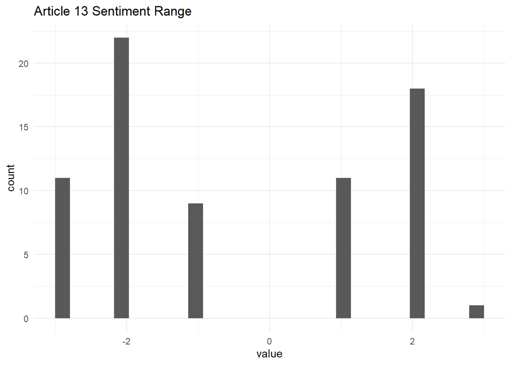

```r
#View(NEarticle13_affin)

ggplot(data = NEarticle13_affin,
       aes(x=value)
        )+
  geom_histogram()+
  ggtitle("Article 13 Sentiment Range")+
  theme_minimal()
```

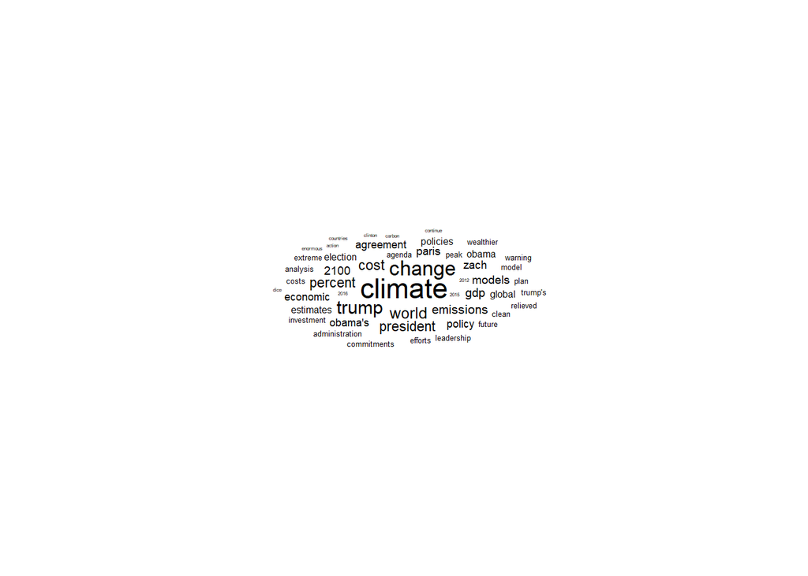

```r
#Could also do simple word clouds as we see
#below uses the ggwordcloud package

set.seed(42)
ggplot(NEarticle13[1:50,], aes(label = word, size = n)
       ) +
  geom_text_wordcloud() +
  theme_minimal()
```

## Article: White House targeting economic risks from climate change

Newspaper: The Associated Press

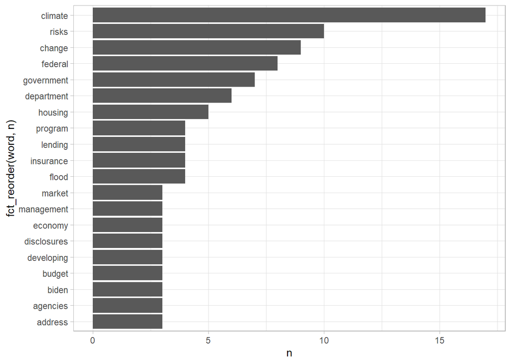

```r
NEarticle14 <- read_lines("07_text_mining/White House targeting economic risks from climate change.txt")

NEarticle14 <- tibble(NEarticle14)
#View(NEarticle14)

NEarticle14$NEarticle14 <- as.character(NEarticle14$NEarticle14)

NEarticle14 <- NEarticle14 %>%
  unnest_tokens(word, NEarticle14)%>%
  anti_join(stop_words)%>%
  count(word, sort=TRUE)
#View(NEarticle14)

ggplot(
  data = NEarticle14[1:20,],
  aes(x = fct_reorder(word,n),
      y = n)
  ) +
  geom_col() +
  coord_flip()+
  theme_light()
```

```r
#evaluating words for their connotation
NEarticle14_affin <- NEarticle14 %>%
  inner_join(get_sentiments("afinn"))#using a inner join to match words and add the sentiment variable
NEarticle14_nrc <- NEarticle14 %>%
  inner_join(get_sentiments("nrc"))
NEarticle14_bing <- NEarticle14 %>%
  inner_join(get_sentiments("bing"))
#We can just do some tabling to see the differences in bing and nrc, seems like Kennedy's speech at least first glanced was much more balanced in terms of negative/positive sentiment
table(NEarticle14_bing$sentiment) #much more positive
```

```
##
## negative positive
##        9        6
```

```r
table(NEarticle14_nrc$sentiment)
```

```
##
##        anger anticipation      disgust         fear          joy     negative
##            4           10            2           12            3           12
##     positive      sadness     surprise        trust
##           21            4            4           19
```

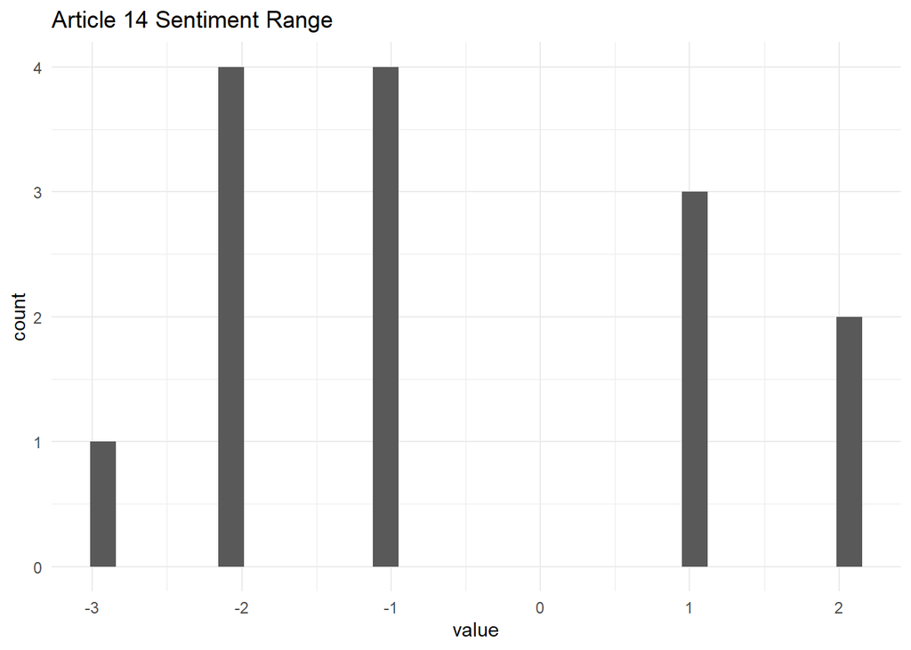

```r
#View(NEarticle14_affin)

ggplot(data = NEarticle14_affin,
       aes(x=value)
        )+
  geom_histogram()+
  ggtitle("Article 14 Sentiment Range")+
  theme_minimal()
```

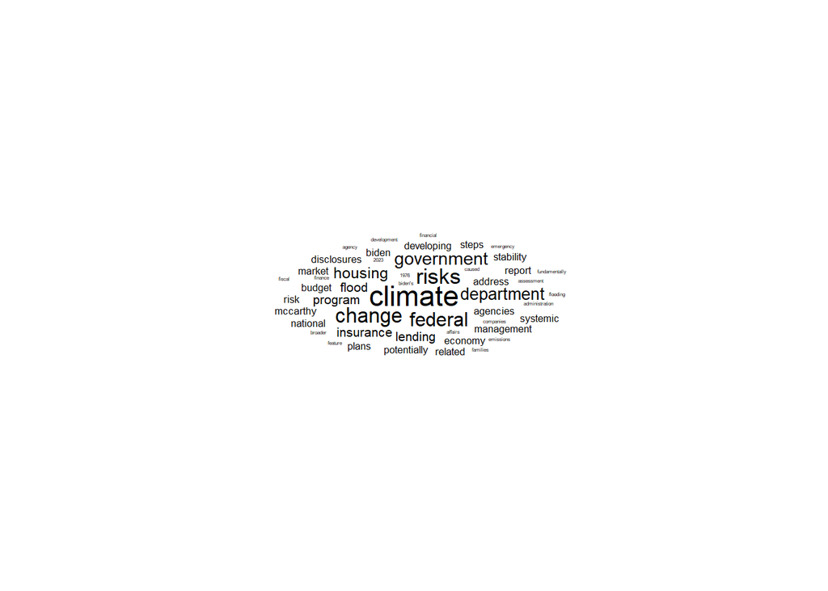

```r
#Could also do simple word clouds as we see
#below uses the ggwordcloud package

set.seed(42)
ggplot(NEarticle14[1:50,], aes(label = word, size = n)
       ) +
  geom_text_wordcloud() +
  theme_minimal()
```

## Article: Teaching About Climate Change With The New York Times

Newspaper: The New York Times Blog

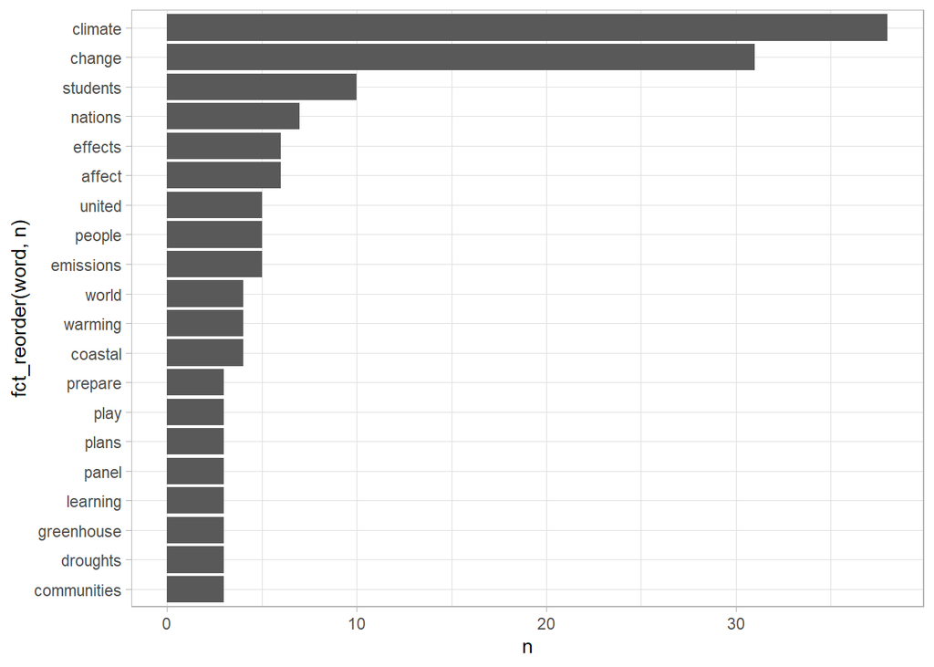

```r
NEarticle15 <- read_lines("07_text_mining/Teaching.txt")

NEarticle15 <- tibble(NEarticle15)
#View(NEarticle15)

NEarticle15$NEarticle15 <- as.character(NEarticle15$NEarticle15)

NEarticle15 <- NEarticle15 %>%
  unnest_tokens(word, NEarticle15)%>%
  anti_join(stop_words)%>%
  count(word, sort=TRUE)
#View(NEarticle15)

ggplot(
  data = NEarticle15[1:20,],
  aes(x = fct_reorder(word,n),
      y = n)
  ) +
  geom_col() +
  coord_flip()+
  theme_light()
```

```r
#evaluating words for their connotation
NEarticle15_affin <- NEarticle15 %>%
  inner_join(get_sentiments("afinn"))#using a inner join to match words and add the sentiment variable
NEarticle15_nrc <- NEarticle15 %>%
  inner_join(get_sentiments("nrc"))
NEarticle15_bing <- NEarticle15 %>%
  inner_join(get_sentiments("bing"))
#We can just do some tabling to see the differences in bing and nrc, seems like Kennedy's speech at least first glanced was much more balanced in terms of negative/positive sentiment
table(NEarticle15_bing$sentiment) #much more positive
```

```
##
## negative positive
##       18        4
```

```r
table(NEarticle15_nrc$sentiment)
```

```
##
##        anger anticipation      disgust         fear          joy     negative
##            8           11            2           13            6           12
##     positive      sadness     surprise        trust
##           28            8            1           16
```

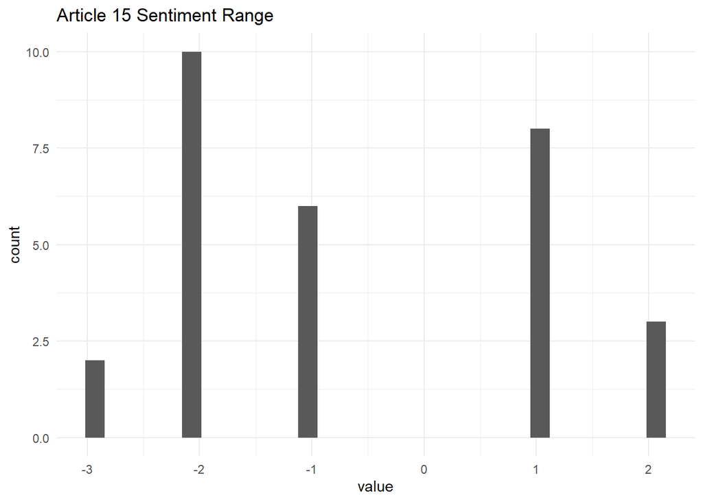

```r
#View(NEarticle15_affin)

ggplot(data = NEarticle15_affin,
       aes(x=value)
        )+
  geom_histogram()+
  ggtitle("Article 15 Sentiment Range")+
  theme_minimal()
```

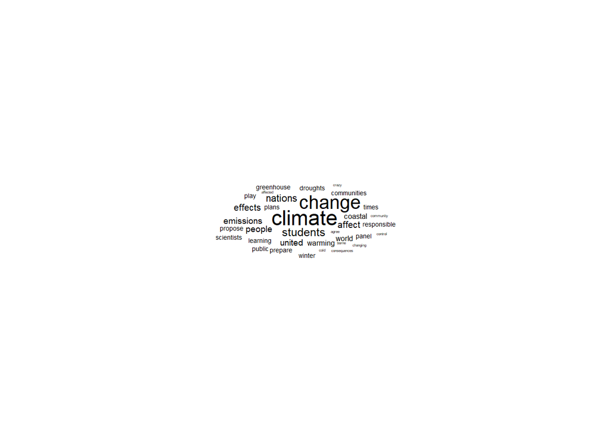

```r
#Could also do simple word clouds as we see
#below uses the ggwordcloud package

set.seed(42)
ggplot(NEarticle15[1:35,], aes(label = word, size = n)
       ) +
  geom_text_wordcloud() +
  theme_minimal()
```

# All the articles in the Northeast region of the US

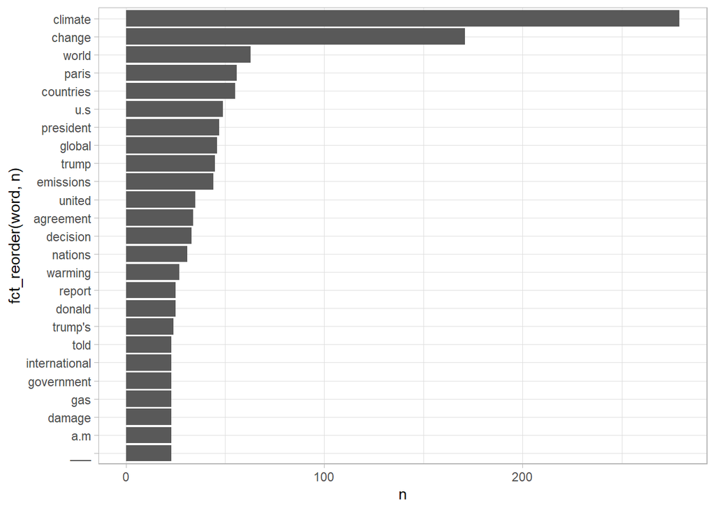

```r
NE_total <- read_lines("07_text_mining/NE_total.txt")

NE_total <- tibble(NE_total)

NE_total$NE_total <- as.character(NE_total$NE_total)

NE_total <- NE_total %>%
  unnest_tokens(word, NE_total)%>%
  anti_join(stop_words)%>%
  count(word, sort=TRUE)
#View(NE_total)

ggplot(
  data = NE_total[1:25,],
  aes(x = fct_reorder(word,n),
      y = n)
  ) +
  geom_col() +
  coord_flip()+
  theme_light()
```

```r
#evaluating words for their connotation
NE_total_affin <- NE_total %>%
  inner_join(get_sentiments("afinn"))#using a inner join to match words and add the sentiment variable
NE_total_nrc <- NE_total %>%
  inner_join(get_sentiments("nrc"))
NE_total_bing <- NE_total %>%
  inner_join(get_sentiments("bing"))
#We can just do some tabling to see the differences in bing and nrc, seems like Kennedy's speech at least first glanced was much more balanced in terms of negative/positive sentiment
table(NE_total_bing$sentiment) #much more positive
```

```
##
## negative positive
##      279      182
```

```r
table(NE_total_nrc$sentiment)
```

```
##
##        anger anticipation      disgust         fear          joy     negative
##          101          133           70          134           88          253
##     positive      sadness     surprise        trust
##          339          116           64          192
```

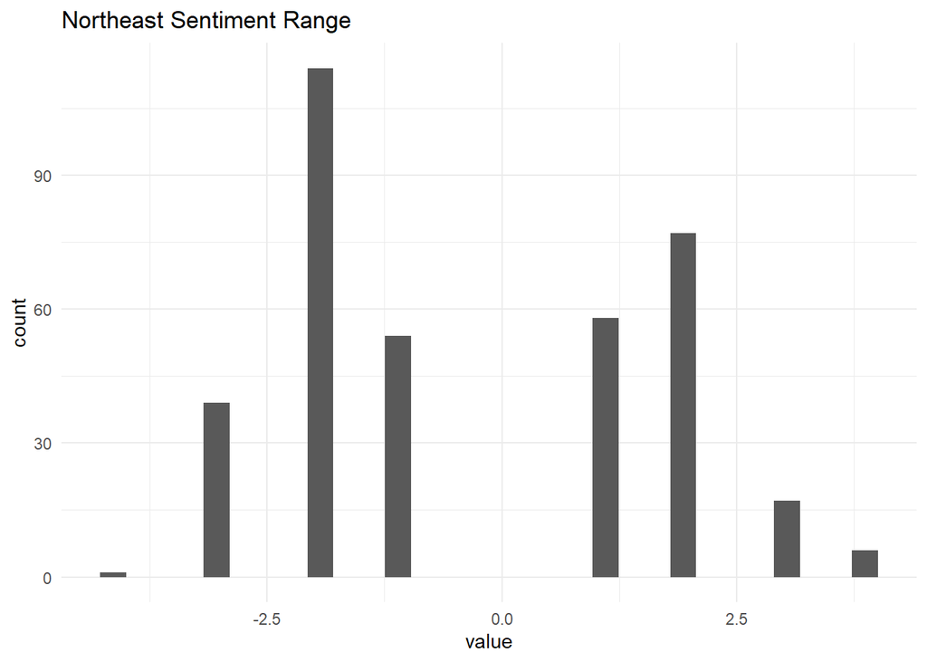

```r
ggplot(data = NE_total_affin,
       aes(x=value)
        )+
  geom_histogram()+
  ggtitle("Northeast Sentiment Range")+
  theme_minimal()
```

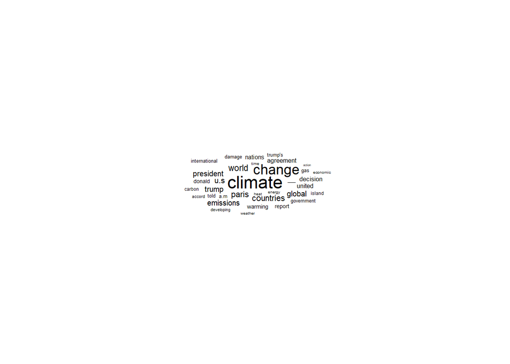

```r
#Could also do simple word clouds as we see
#below uses the ggwordcloud package

set.seed(42)
ggplot(NE_total[1:35,], aes(label = word, size = n)
       ) +
  geom_text_wordcloud() +
  theme_minimal()
```

```r
#need to the raw data again
NEarticle1_raw <- as.tibble(read_lines("07_text_mining/Adapt-or-Die.txt"))
NEarticle2_raw <- as.tibble(read_lines("07_text_mining/Blame Climate Change for the Weather.txt"))
NEarticle3_raw <- as.tibble(read_lines("07_text_mining/Destroying-My-Country.txt"))
NEarticle4_raw <- as.tibble(read_lines("07_text_mining/England must.txt"))
NEarticle5_raw <- as.tibble(read_lines("07_text_mining/Fossil-Fuel-Peak.txt"))
NEarticle6_raw <- as.tibble(read_lines("07_text_mining/Google bans ads.txt"))
NEarticle7_raw <- as.tibble(read_lines("07_text_mining/How the Animal World Is Adapting to Climate Change_ Non.txt"))
NEarticle8_raw <- as.tibble(read_lines("07_text_mining/Looking out for number 2_ Farmer has a manure solution.txt"))
NEarticle9_raw <- as.tibble(read_lines("07_text_mining/Potsdam town and village recognized for climate change.txt"))
NEarticle10_raw <- as.tibble(read_lines("07_text_mining/Share-the-Cost-of-Climate-Change.txt"))
NEarticle11_raw <- as.tibble(read_lines("07_text_mining/Small islands.txt"))
NEarticle12_raw <- as.tibble(read_lines("07_text_mining/The Latest_ EPA.txt"))
NEarticle13_raw <- as.tibble(read_lines("07_text_mining/Trump the Climate-Slayer.txt"))
NEarticle14_raw <- as.tibble(read_lines("07_text_mining/White House targeting economic risks from climate change.txt"))
NEarticle15_raw <- as.tibble(read_lines("07_text_mining/Teaching.txt"))

data_prep <- function(x,y,z){
  i <- as_tibble(t(x))
  ii <- unite(i,"text",y:z,remove = TRUE,sep = "") #the function merges everything into one cell (box)
}

NEarticle1_bag <- data_prep(NEarticle1_raw,'V1','V18')
```

```
## Note: Using an external vector in selections is ambiguous.
## i Use `all_of(y)` instead of `y` to silence this message.
## i See <https://tidyselect.r-lib.org/reference/faq-external-vector.html>.
```

```
## Note: Using an external vector in selections is ambiguous.
## i Use `all_of(z)` instead of `z` to silence this message.
## i See <https://tidyselect.r-lib.org/reference/faq-external-vector.html>.
```

```r
NEarticle2_bag <- data_prep(NEarticle2_raw,'V1','V16')
NEarticle3_bag <- data_prep(NEarticle3_raw,'V1','V26')
NEarticle4_bag <- data_prep(NEarticle4_raw,'V1','V9')
NEarticle5_bag <- data_prep(NEarticle5_raw,'V1','V20')
NEarticle6_bag <- data_prep(NEarticle6_raw,'V1','V10')
NEarticle7_bag <- data_prep(NEarticle7_raw,'V1','V16')
NEarticle8_bag <- data_prep(NEarticle8_raw,'V1','V27')
NEarticle9_bag <- data_prep(NEarticle9_raw,'V1','V13')
NEarticle10_bag <- data_prep(NEarticle10_raw,'V1','V13')
NEarticle11_bag <- data_prep(NEarticle11_raw,'V1','V30')
NEarticle12_bag <- data_prep(NEarticle12_raw,'V1','V159')
NEarticle13_bag <- data_prep(NEarticle13_raw,'V1','V23')
NEarticle14_bag <- data_prep(NEarticle14_raw,'V1','V15')
NEarticle15_bag <- data_prep(NEarticle15_raw,'V1','V21')

NE_articles <- c("Northeast Article 1", "Northeast Article 2", "Northeast Article 3", "Northeast Article 4", "Northeast Article 5", "Northeast Article 6", "Northeast Article 7", "Northeast Article 8", "Northeast Article 9", "Northeast Article 10", "Northeast Article 11", "Northeast Article 12", "Northeast Article 13", "Northeast Article 14", "Northeast Article 15")


NE_tf_idf_text <- tibble(NE_articles,text=t(tibble(NEarticle1_bag, NEarticle2_bag, NEarticle3_bag, NEarticle4_bag, NEarticle5_bag, NEarticle6_bag, NEarticle7_bag, NEarticle8_bag, NEarticle9_bag, NEarticle10_bag, NEarticle11_bag, NEarticle12_bag, NEarticle13_bag, NEarticle14_bag, NEarticle15_bag, .name_repair = "universal")))
```

```
## * text -> text...1
## * text -> text...2
## * text -> text...3
## * text -> text...4
## * text -> text...5
## * ...
```

```r
View(NE_tf_idf_text)

NE_word_count <- NE_tf_idf_text %>%
  unnest_tokens(word, text) %>%
  count(NE_articles, word, sort = TRUE)
view(NE_word_count)

NE_total_words <- NE_word_count %>%
  group_by(NE_articles) %>%
  summarize(total = sum(n))
(NE_total_words)
```

```
## # A tibble: 15 x 2
##    NE_articles          total
##    <chr>                <int>
##  1 Northeast Article 1    700
##  2 Northeast Article 10   731
##  3 Northeast Article 11  1270
##  4 Northeast Article 12  2957
##  5 Northeast Article 13  1826
##  6 Northeast Article 14   639
##  7 Northeast Article 15   936
##  8 Northeast Article 2   1015
##  9 Northeast Article 3   3434
## 10 Northeast Article 4    283
## 11 Northeast Article 5   1056
## 12 Northeast Article 6    421
## 13 Northeast Article 7   1230
## 14 Northeast Article 8   1018
## 15 Northeast Article 9    369
```

```r
NE_inag_words <- left_join(NE_word_count, NE_total_words)
(NE_inag_words)
```

```
## # A tibble: 7,590 x 4
##    NE_articles          word      n total
##    <chr>                <chr> <int> <int>
##  1 Northeast Article 3  the     225  3434
##  2 Northeast Article 12 the     220  2957
##  3 Northeast Article 13 the     128  1826
##  4 Northeast Article 3  and     118  3434
##  5 Northeast Article 12 to      103  2957
##  6 Northeast Article 3  of       94  3434
##  7 Northeast Article 11 the      85  1270
##  8 Northeast Article 3  to       84  3434
##  9 Northeast Article 12 of       77  2957
## 10 Northeast Article 8  the      76  1018
## # ... with 7,580 more rows
```

```r
NE_inag_words <- NE_inag_words %>%
  bind_tf_idf(word, NE_articles, n) #n represents frequency counts
view(NE_inag_words)

#in inag_words, the words like 'the' and 'and' and other common words have an tf_idf of 0 because they are insignificant and pop up alot.
#sort by tf_idf to see most significant words
#tf*idf = tf_idf
```

## Reflection about the Northeastern Region:

The 15 articles come from a variety of different newspapers from the region in order to gain a better understanding of how the region views the issue of climate change. I collected articles from the newspapers, The New York Times, The Associated Press, The Philadelphia Daily News, and the National Review. In the Northeast region, common terms are ‘world’, ‘countries’, and ‘global.’ This shows me that they are thinking about the big picture when considering this topic. Other terms that can be grouped together are ‘emissions’, ‘warming’, and ‘damage.’ This shows that they view the issue factually. There are more negative terms than positive.

# Southeast Region of the US

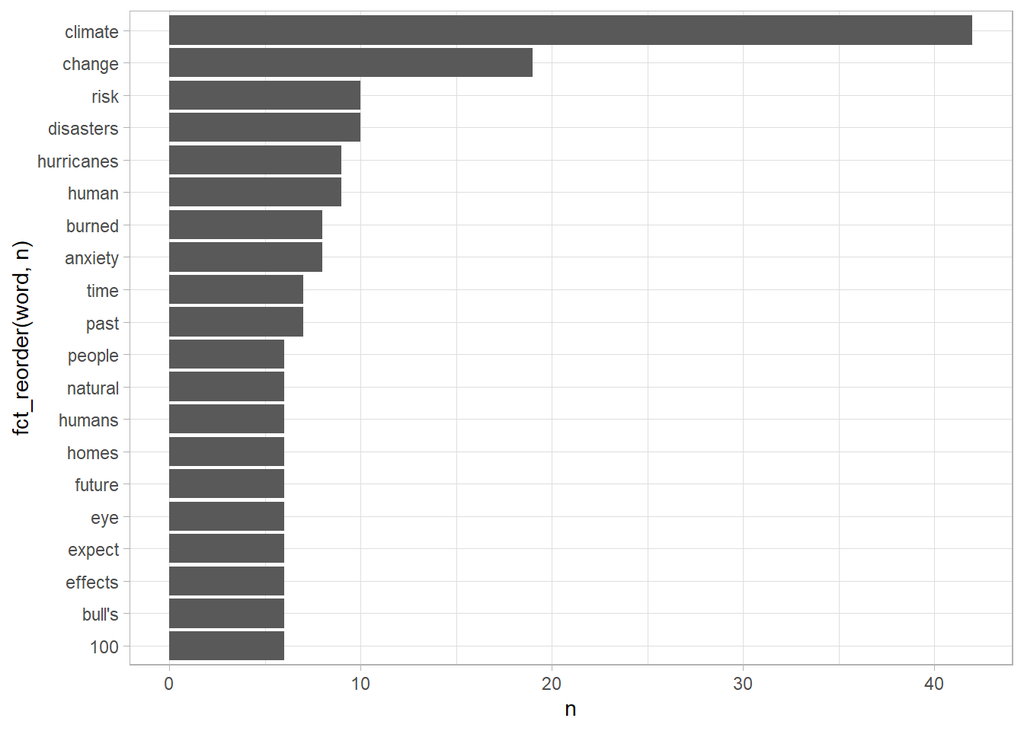

```r
SEarticle16 <- read_lines("07_text_mining/3_myths.txt")

SEarticle16 <- tibble(SEarticle16)
#View(SEarticle16)

SEarticle16$SEarticle16 <- as.character(SEarticle16$SEarticle16)

SEarticle16 <- SEarticle16 %>%
  unnest_tokens(word, SEarticle16)%>%
  anti_join(stop_words)%>%
  count(word, sort=TRUE)
#View(SEarticle16)

ggplot(
  data = SEarticle16[1:20,],
  aes(x = fct_reorder(word,n),
      y = n)
  ) +
  geom_col() +
  coord_flip()+
  theme_light()
```

```r
#evaluating words for their connotation
SEarticle16_affin <- SEarticle16 %>%
  inner_join(get_sentiments("afinn"))#using a inner join to match words and add the sentiment variable
SEarticle16_nrc <- SEarticle16 %>%
  inner_join(get_sentiments("nrc"))
SEarticle16_bing <- SEarticle16 %>%
  inner_join(get_sentiments("bing"))
#We can just do some tabling to see the differences in bing and nrc, seems like Kennedy's speech at least first glanced was much more balanced in terms of negative/positive sentiment
table(SEarticle16_bing$sentiment) #much more positive
```

```
##
## negative positive
##       53       15
```

```r
table(SEarticle16_nrc$sentiment)
```

```
##
##        anger anticipation      disgust         fear          joy     negative
##           16           21           13           30           11           44
##     positive      sadness     surprise        trust
##           47           20           13           28
```

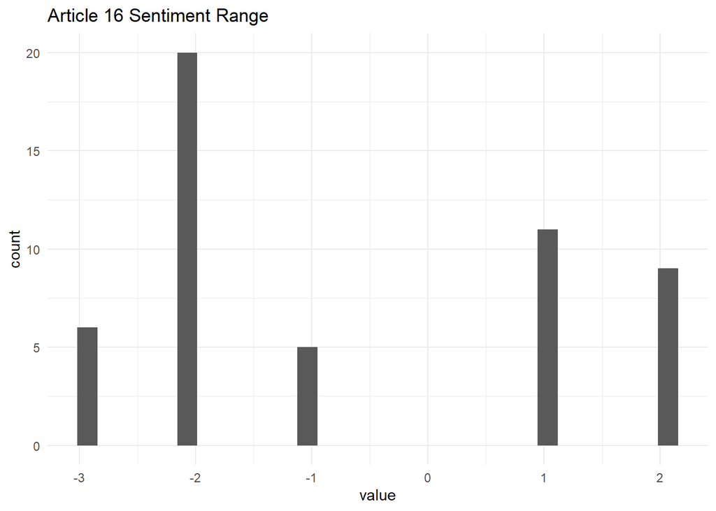

```r
#View(SEarticle16_affin)

ggplot(data = SEarticle16_affin,
       aes(x=value)
        )+
  geom_histogram()+
  ggtitle("Article 16 Sentiment Range")+
  theme_minimal()
```

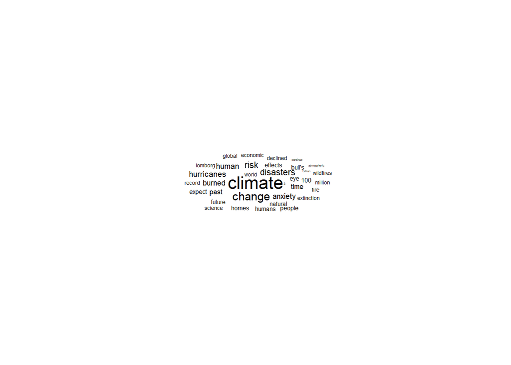

```r
#Could also do simple word clouds as we see
#below uses the ggwordcloud package

set.seed(42)
ggplot(SEarticle16[1:35,], aes(label = word, size = n)
       ) +
  geom_text_wordcloud() +
  theme_minimal()
```

## Article: On climate change, are we too stupid to live?; Columnist Leonard Pitts Jr. weighs in on how climate change, COVID-19 and the Jan. 6 insurrection are related.

Newspaper: Tampa Bay Times

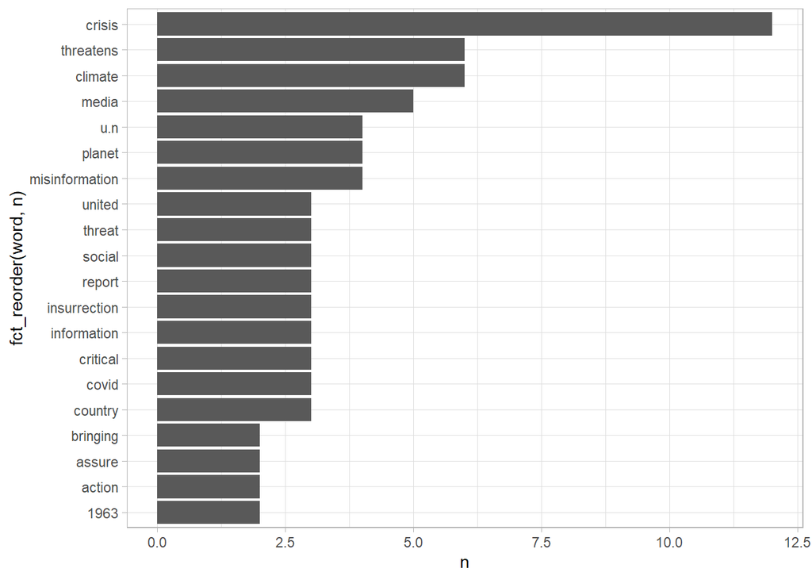

```r
SEarticle17 <- read_lines("07_text_mining/are we too stupid to live.txt")

SEarticle17 <- tibble(SEarticle17)
#View(SEarticle17)

SEarticle17$SEarticle17 <- as.character(SEarticle17$SEarticle17)

SEarticle17 <- SEarticle17 %>%
  unnest_tokens(word, SEarticle17)%>%
  anti_join(stop_words)%>%
  count(word, sort=TRUE)
#View(SEarticle17)

ggplot(
  data = SEarticle17[1:20,],
  aes(x = fct_reorder(word,n),
      y = n)
  ) +
  geom_col() +
  coord_flip()+
  theme_light()
```

```r
#evaluating words for their connotation
SEarticle17_affin <- SEarticle17 %>%
  inner_join(get_sentiments("afinn"))#using a inner join to match words and add the sentiment variable
SEarticle17_nrc <- SEarticle17 %>%
  inner_join(get_sentiments("nrc"))
SEarticle17_bing <- SEarticle17 %>%
  inner_join(get_sentiments("bing"))
#We can just do some tabling to see the differences in bing and nrc, seems like Kennedy's speech at least first glanced was much more balanced in terms of negative/positive sentiment
table(SEarticle17_bing$sentiment) #much more positive
```

```
##
## negative positive
##       35        9
```

```r
table(SEarticle17_nrc$sentiment)
```

```
##
##        anger anticipation      disgust         fear          joy     negative
##           10           10            8           17            2           26
##     positive      sadness     surprise        trust
##           23           14            8           14
```

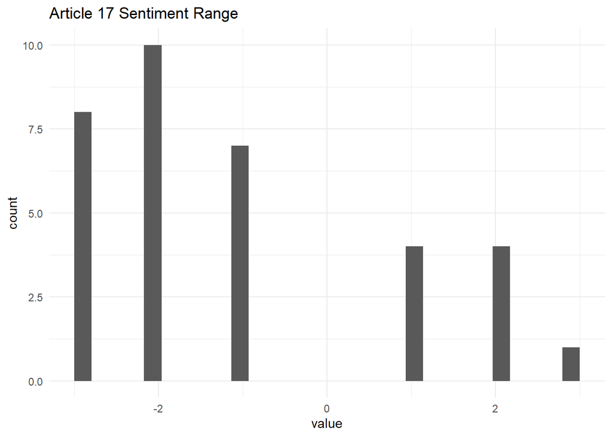

```r
#View(SEarticle17_affin)

ggplot(data = SEarticle17_affin,
       aes(x=value)
        )+
  geom_histogram()+
  ggtitle("Article 17 Sentiment Range")+
  theme_minimal()
```

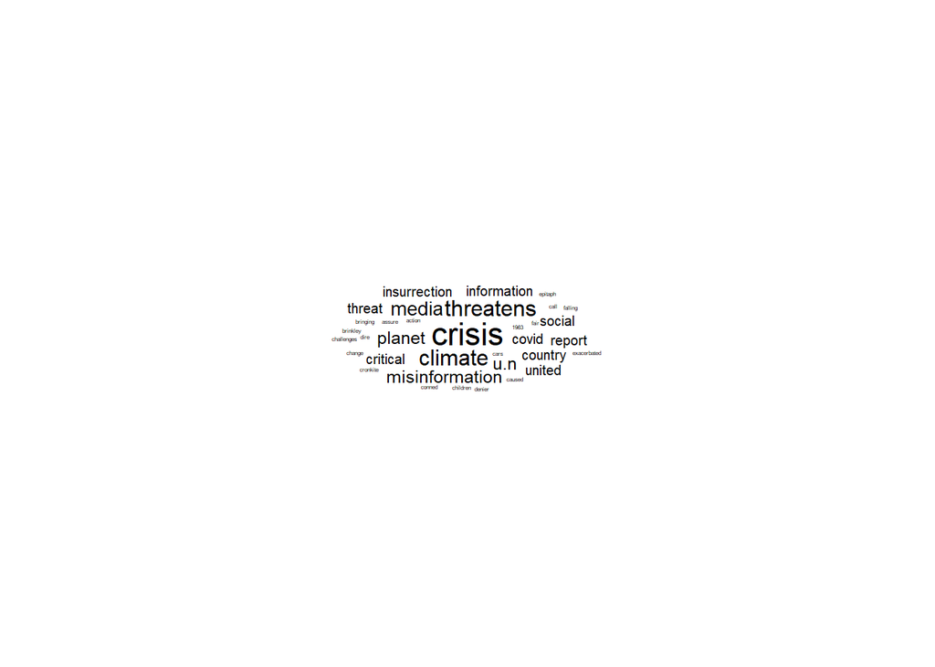

```r
#Could also do simple word clouds as we see
#below uses the ggwordcloud package

set.seed(42)
ggplot(SEarticle17[1:35,], aes(label = word, size = n)
       ) +
  geom_text_wordcloud() +
  theme_minimal()
```

## Article: Climate activist Nakate seeks immediate action from world leaders in Glasgow; Nakate is among 400 activists invited to a three-day Youth4Climate meeting that will draft a document for the U.N.’s 26th Climate Change Conference.

Newspaper: Tampa Bay Times

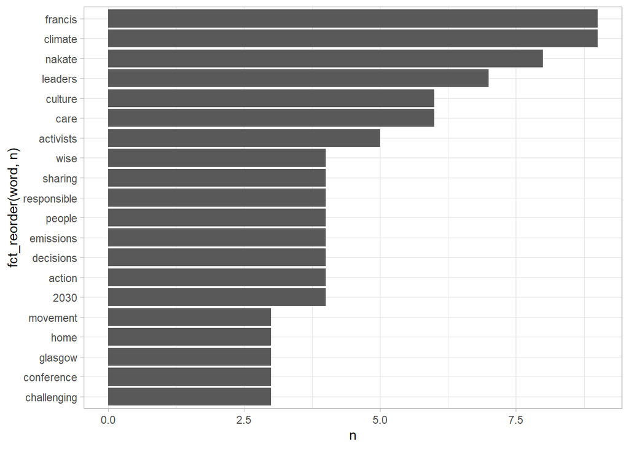

```r
SEarticle18 <- read_lines("07_text_mining/Climate activist Nakate.txt")

SEarticle18 <- tibble(SEarticle18)
#View(SEarticle18)

SEarticle18$SEarticle18 <- as.character(SEarticle18$SEarticle18)

SEarticle18 <- SEarticle18 %>%
  unnest_tokens(word, SEarticle18)%>%
  anti_join(stop_words)%>%
  count(word, sort=TRUE)
#View(SEarticle18)

ggplot(
  data = SEarticle18[1:20,],
  aes(x = fct_reorder(word,n),
      y = n)
  ) +
  geom_col() +
  coord_flip()+
  theme_light()
```

```r
#evaluating words for their connotation
SEarticle18_affin <- SEarticle18 %>%
  inner_join(get_sentiments("afinn"))#using a inner join to match words and add the sentiment variable
SEarticle18_nrc <- SEarticle18 %>%
  inner_join(get_sentiments("nrc"))
SEarticle18_bing <- SEarticle18 %>%
  inner_join(get_sentiments("bing"))
#We can just do some tabling to see the differences in bing and nrc, seems like Kennedy's speech at least first glanced was much more balanced in terms of negative/positive sentiment
table(SEarticle18_bing$sentiment) #much more positive
```

```
##
## negative positive
##        8       10
```

```r
table(SEarticle18_nrc$sentiment)
```

```
##
##        anger anticipation      disgust         fear          joy     negative
##            7            9            3            7            5            9
##     positive      sadness     surprise        trust
##           27            5            3           12
```

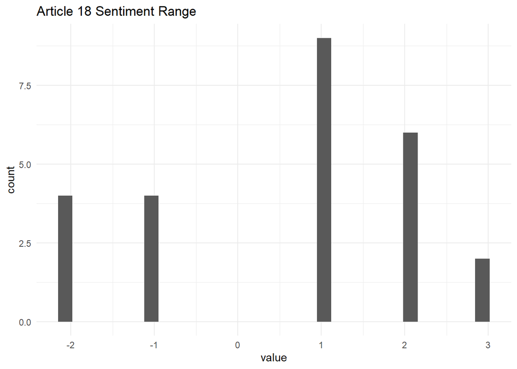

```r
#View(SEarticle18_affin)

ggplot(data = SEarticle18_affin,
       aes(x=value)
        )+
  geom_histogram()+
  ggtitle("Article 18 Sentiment Range")+
  theme_minimal()
```

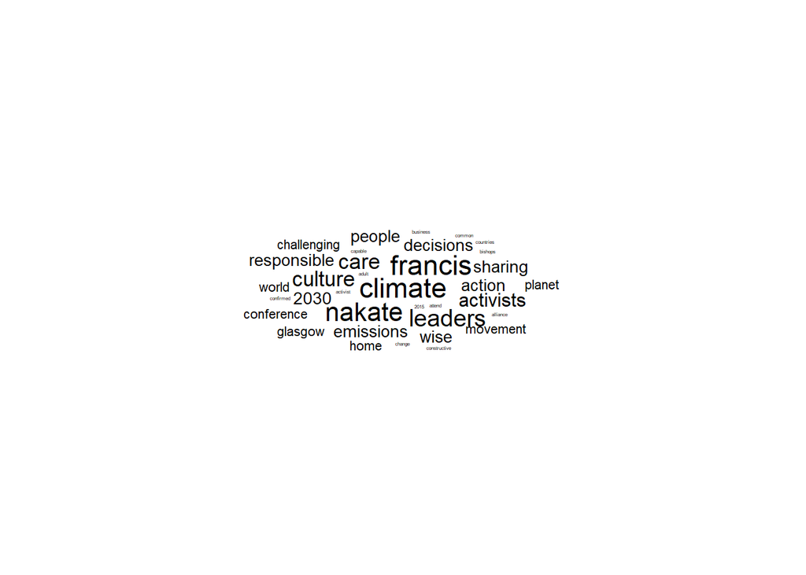

```r
#Could also do simple word clouds as we see
#below uses the ggwordcloud package

set.seed(42)
ggplot(SEarticle18[1:35,], aes(label = word, size = n)
       ) +
  geom_text_wordcloud() +
  theme_minimal()
```

## Article: CLIMATE CHANGE ENTERS DEBATE

Newspaper: Tampa Bay Times

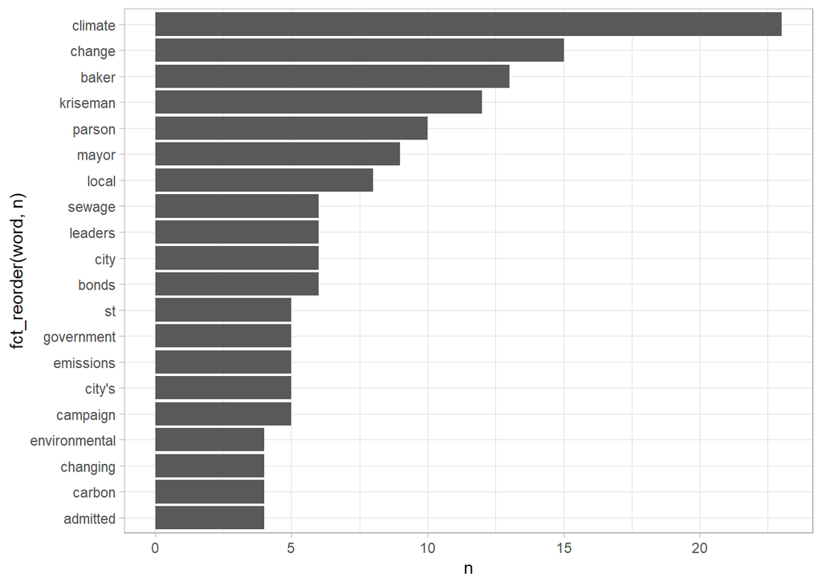

```r
SEarticle19 <- read_lines("07_text_mining/CLIMATE-CHANGE-ENTERS-DEBATE.txt")

SEarticle19 <- tibble(SEarticle19)
#View(SEarticle19)

SEarticle19$SEarticle19 <- as.character(SEarticle19$SEarticle19)

SEarticle19 <- SEarticle19 %>%
  unnest_tokens(word, SEarticle19)%>%
  anti_join(stop_words)%>%
  count(word, sort=TRUE)
#View(SEarticle19)

ggplot(
  data = SEarticle19[1:20,],
  aes(x = fct_reorder(word,n),
      y = n)
  ) +
  geom_col() +
  coord_flip()+
  theme_light()
```

```r
#evaluating words for their connotation
SEarticle19_affin <- SEarticle19 %>%
  inner_join(get_sentiments("afinn"))#using a inner join to match words and add the sentiment variable
SEarticle19_nrc <- SEarticle19 %>%
  inner_join(get_sentiments("nrc"))
SEarticle19_bing <- SEarticle19 %>%
  inner_join(get_sentiments("bing"))
#We can just do some tabling to see the differences in bing and nrc, seems like Kennedy's speech at least first glanced was much more balanced in terms of negative/positive sentiment
table(SEarticle19_bing$sentiment) #much more positive
```

```
##
## negative positive
##       25       11
```

```r
table(SEarticle19_nrc$sentiment)
```

```
##
##        anger anticipation      disgust         fear          joy     negative
##            9           11            4           10            7           19
##     positive      sadness     surprise        trust
##           34            3            3           21
```

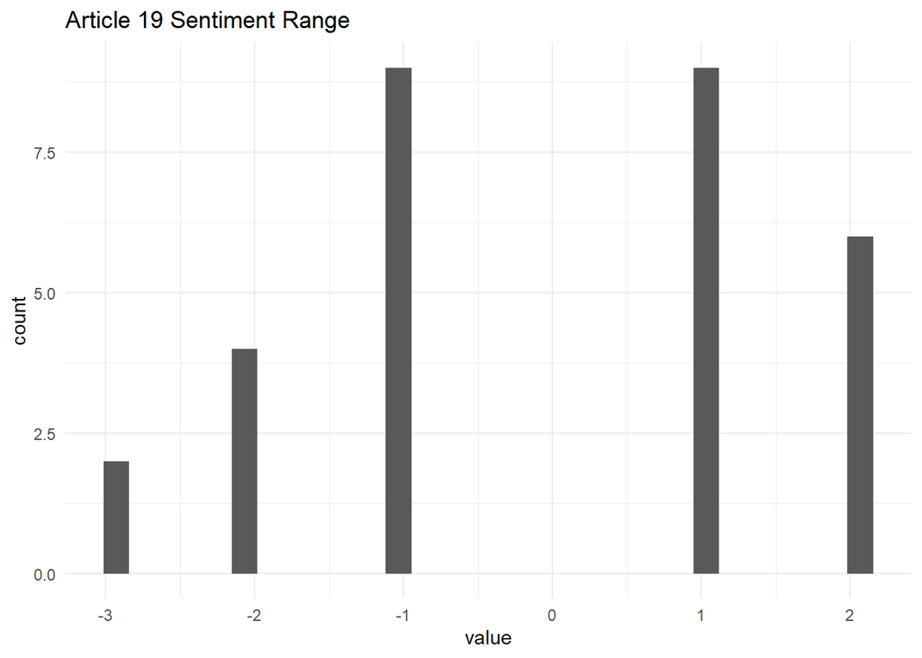

```r
#View(SEarticle19_affin)

ggplot(data = SEarticle19_affin,
       aes(x=value)
        )+
  geom_histogram()+
  ggtitle("Article 19 Sentiment Range")+
  theme_minimal()
```

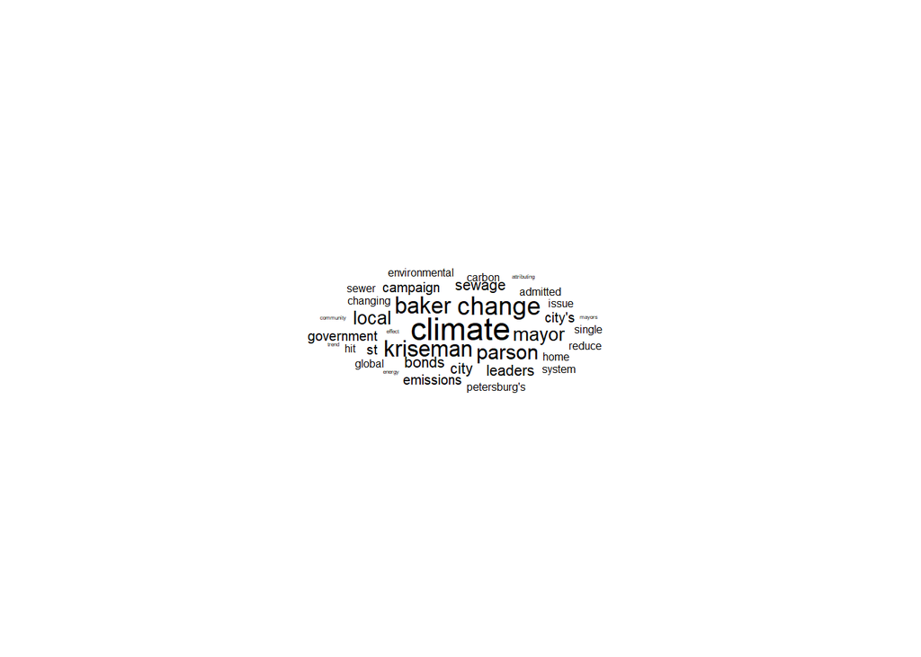

```r
#Could also do simple word clouds as we see
#below uses the ggwordcloud package

set.seed(42)
ggplot(SEarticle19[1:35,], aes(label = word, size = n)
       ) +
  geom_text_wordcloud() +
  theme_minimal()
```

## Article: As extreme weather increases, climate misinformation adapts; Climate denialism isn’t the only problem. Misinformation merchants are trying to diminish the impact of climate change on extreme weather events.

Newspaper: Tampa Bay Times

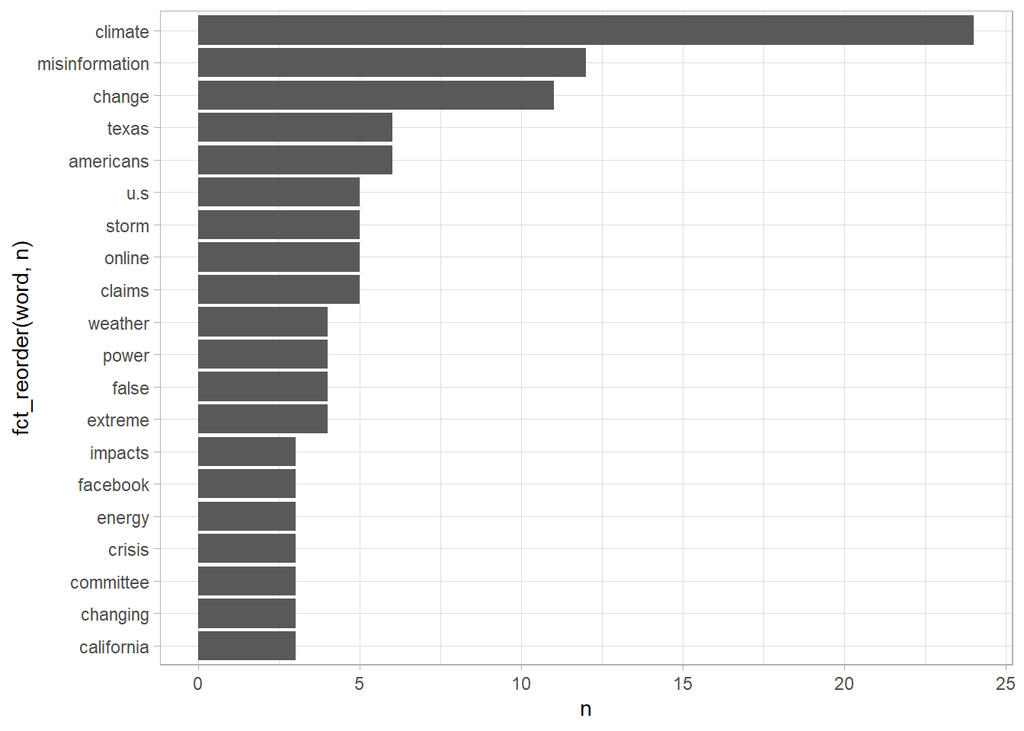

```r
SEarticle20 <- read_lines("07_text_mining/climate-misinformation.txt")

SEarticle20 <- tibble(SEarticle20)
#View(SEarticle20)

SEarticle20$SEarticle20 <- as.character(SEarticle20$SEarticle20)

SEarticle20 <- SEarticle20 %>%
  unnest_tokens(word, SEarticle20)%>%
  anti_join(stop_words)%>%
  count(word, sort=TRUE)
#View(SEarticle20)

ggplot(
  data = SEarticle20[1:20,],
  aes(x = fct_reorder(word,n),
      y = n)
  ) +
  geom_col() +
  coord_flip()+
  theme_light()
```

```r
#evaluating words for their connotation
SEarticle20_affin <- SEarticle20 %>%
  inner_join(get_sentiments("afinn"))#using a inner join to match words and add the sentiment variable
SEarticle20_nrc <- SEarticle20 %>%
  inner_join(get_sentiments("nrc"))
SEarticle20_bing <- SEarticle20 %>%
  inner_join(get_sentiments("bing"))
#We can just do some tabling to see the differences in bing and nrc, seems like Kennedy's speech at least first glanced was much more balanced in terms of negative/positive sentiment
table(SEarticle20_bing$sentiment) #much more positive
```

```
##
## negative positive
##       27       12
```

```r
table(SEarticle20_nrc$sentiment)
```

```
##
##        anger anticipation      disgust         fear          joy     negative
##           12           12            4           14            4           24
##     positive      sadness     surprise        trust
##           29            5            3           27
```

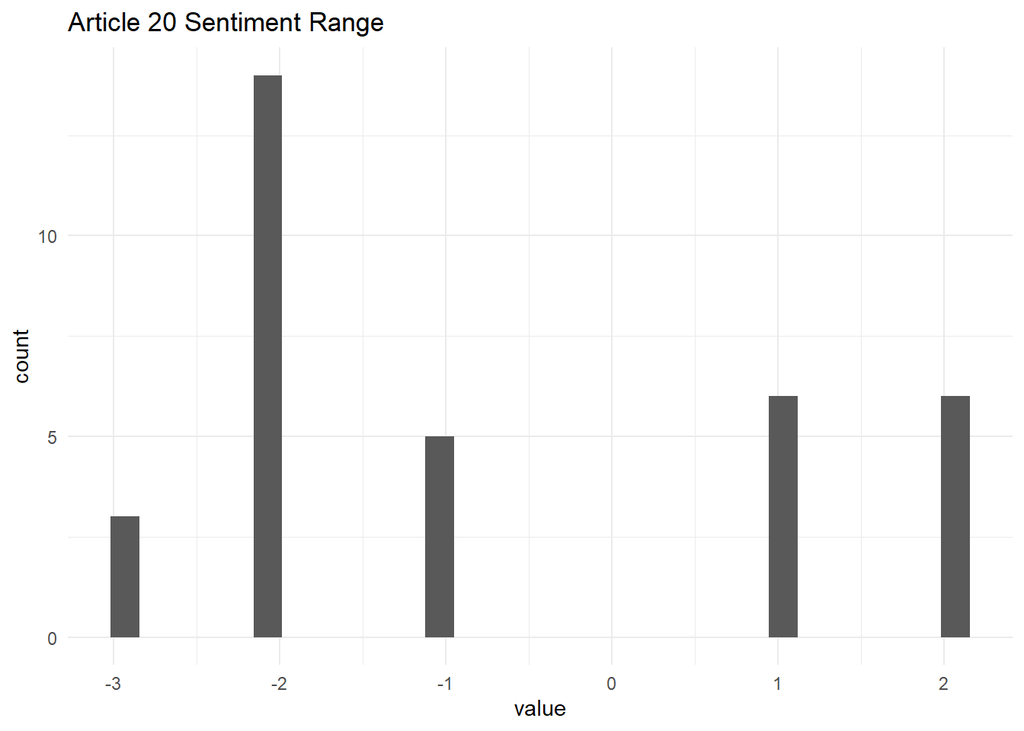

```r
#View(SEarticle20_affin)

ggplot(data = SEarticle20_affin,
       aes(x=value)
        )+
  geom_histogram()+
  ggtitle("Article 20 Sentiment Range")+
  theme_minimal()
```

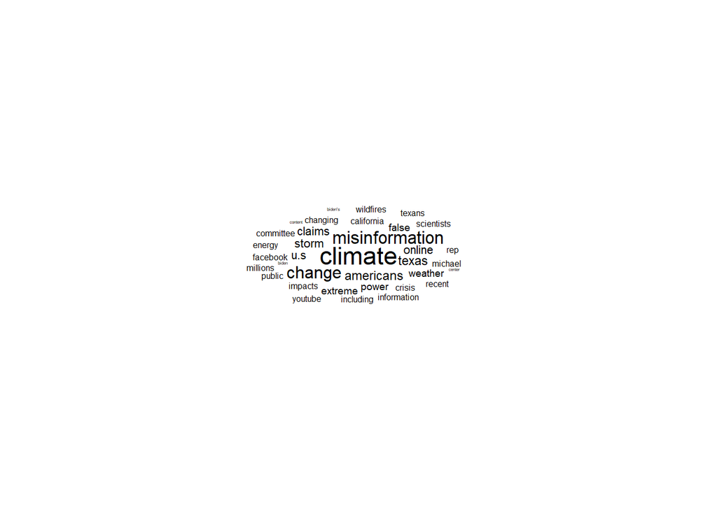

```r
#Could also do simple word clouds as we see
#below uses the ggwordcloud package

set.seed(42)
ggplot(SEarticle20[1:35,], aes(label = word, size = n)
       ) +
  geom_text_wordcloud() +
  theme_minimal()
```

## Article: Florida Legislature can do even more to make us resilient to climate change and sea level rise | Column; Making investments in protecting our “blue economy” now will pay dividends long into the future.

Newspaper: Tampa Bay Times

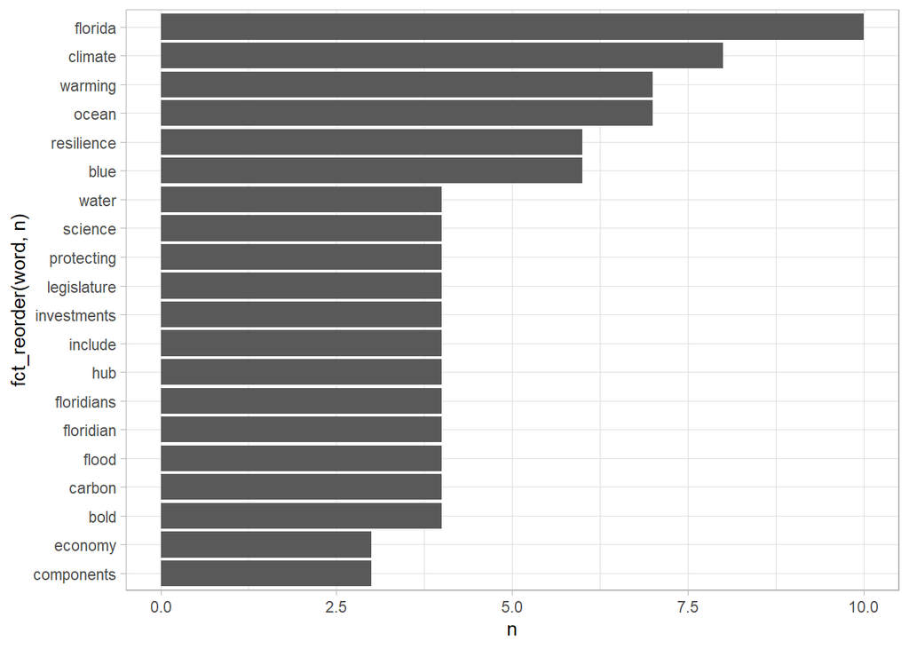

```r
SEarticle21 <- read_lines("07_text_mining/Florida Legislature.txt")

SEarticle21 <- tibble(SEarticle21)
#View(SEarticle21)

SEarticle21$SEarticle21 <- as.character(SEarticle21$SEarticle21)

SEarticle21 <- SEarticle21 %>%
  unnest_tokens(word, SEarticle21)%>%
  anti_join(stop_words)%>%
  count(word, sort=TRUE)
#View(SEarticle21)

ggplot(
  data = SEarticle21[1:20,],
  aes(x = fct_reorder(word,n),
      y = n)
  ) +
  geom_col() +
  coord_flip()+
  theme_light()
```

```r
#evaluating words for their connotation
SEarticle21_affin <- SEarticle21 %>%
  inner_join(get_sentiments("afinn"))#using a inner join to match words and add the sentiment variable
SEarticle21_nrc <- SEarticle21 %>%
  inner_join(get_sentiments("nrc"))
SEarticle21_bing <- SEarticle21 %>%
  inner_join(get_sentiments("bing"))
#We can just do some tabling to see the differences in bing and nrc, seems like Kennedy's speech at least first glanced was much more balanced in terms of negative/positive sentiment
table(SEarticle21_bing$sentiment) #much more positive
```

```
##
## negative positive
##       12       16
```

```r
table(SEarticle21_nrc$sentiment)
```

```
##
##        anger anticipation      disgust         fear          joy     negative
##            4           10            2            5            6            6
##     positive      sadness        trust
##           38            2           23
```

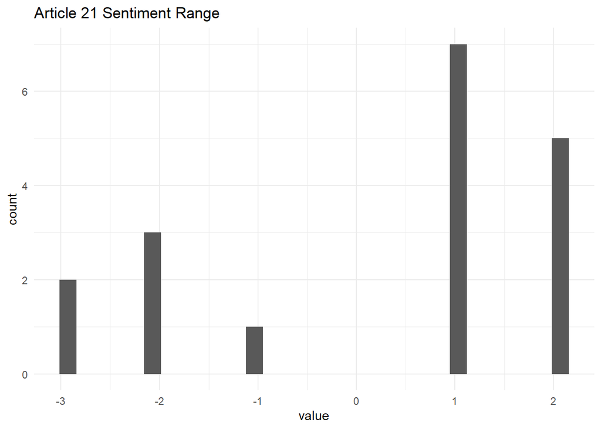

```r
#View(SEarticle21_affin)

ggplot(data = SEarticle21_affin,
       aes(x=value)
        )+
  geom_histogram()+
  ggtitle("Article 21 Sentiment Range")+
  theme_minimal()
```

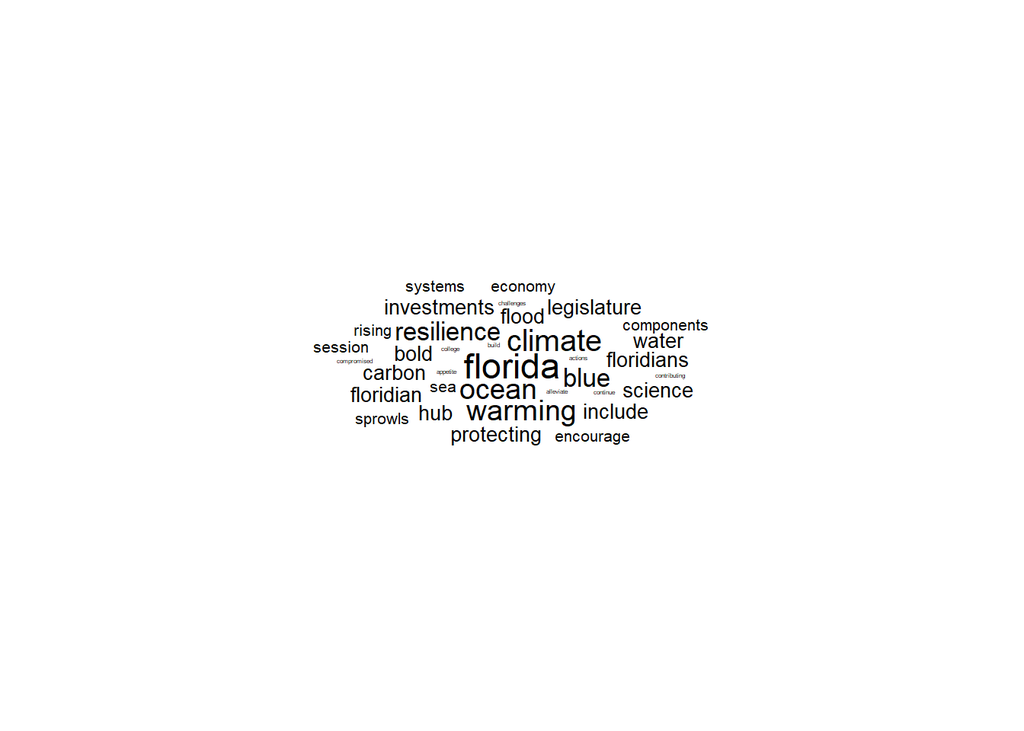

```r
#Could also do simple word clouds as we see
#below uses the ggwordcloud package

set.seed(42)
ggplot(SEarticle21[1:35,], aes(label = word, size = n)
       ) +
  geom_text_wordcloud() +
  theme_minimal()
```

## Article: Most Florida voters worry about climate change. Will Trump talk about it?

Newspaper: Tampa Bay Times

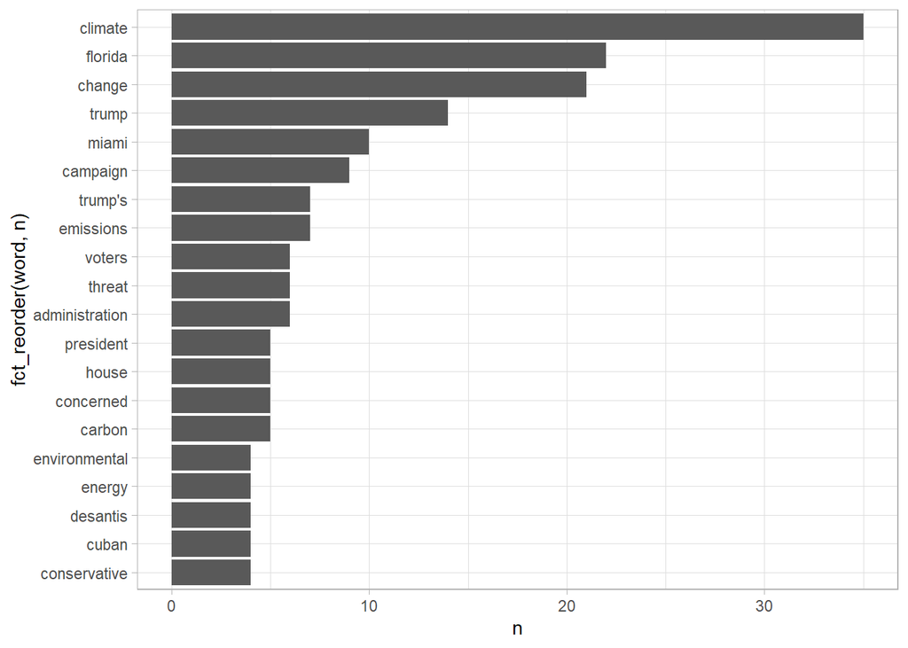

```r
SEarticle22 <- read_lines("07_text_mining/Florida-voters-worry.txt")

SEarticle22 <- tibble(SEarticle22)
#View(SEarticle22)

SEarticle22$SEarticle22 <- as.character(SEarticle22$SEarticle22)

SEarticle22 <- SEarticle22 %>%
  unnest_tokens(word, SEarticle22)%>%
  anti_join(stop_words)%>%
  count(word, sort=TRUE)
#View(SEarticle22)

ggplot(
  data = SEarticle22[1:20,],
  aes(x = fct_reorder(word,n),
      y = n)
  ) +
  geom_col() +
  coord_flip()+
  theme_light()
```

```r
#evaluating words for their connotation
SEarticle22_affin <- SEarticle22 %>%
  inner_join(get_sentiments("afinn"))#using a inner join to match words and add the sentiment variable
SEarticle22_nrc <- SEarticle22 %>%
  inner_join(get_sentiments("nrc"))
SEarticle22_bing <- SEarticle22 %>%
  inner_join(get_sentiments("bing"))
#We can just do some tabling to see the differences in bing and nrc, seems like Kennedy's speech at least first glanced was much more balanced in terms of negative/positive sentiment
table(SEarticle22_bing$sentiment) #much more positive
```

```
##
## negative positive
##       33       24
```

```r
table(SEarticle22_nrc$sentiment)
```

```
##
##        anger anticipation      disgust         fear          joy     negative
##           16           26            6           24           15           36
##     positive      sadness     surprise        trust
##           56           11           11           39
```

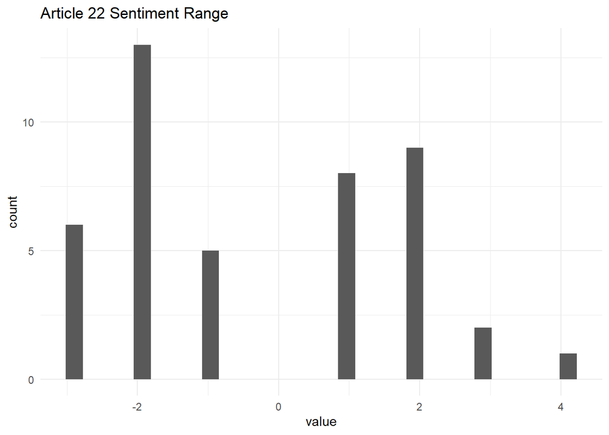

```r
#View(SEarticle22_affin)

ggplot(data = SEarticle22_affin,
       aes(x=value)
        )+
  geom_histogram()+
  ggtitle("Article 22 Sentiment Range")+
  theme_minimal()
```

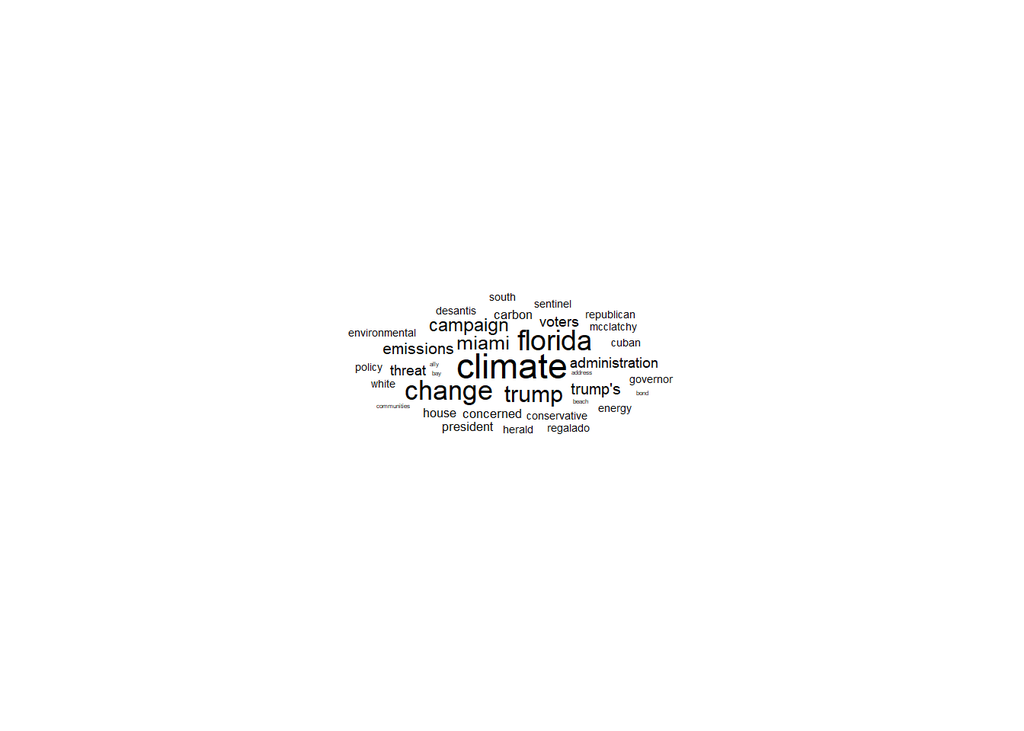

```r
#Could also do simple word clouds as we see
#below uses the ggwordcloud package

set.seed(42)
ggplot(SEarticle22[1:35,], aes(label = word, size = n)
       ) +
  geom_text_wordcloud() +
  theme_minimal()
```

## Article: Experts say climate change can make hurricanes more intense, not cause them; PolitiFact | Experts have not resorted to blaming recent hurricanes on climate change.

Newspaper: Tampa Bay Times

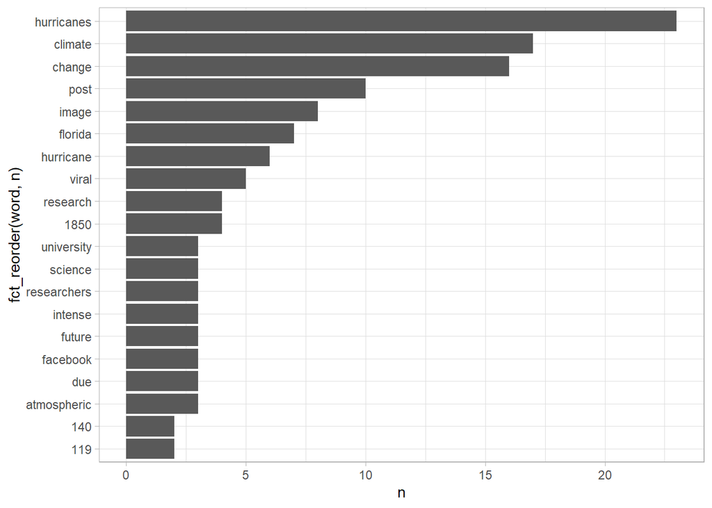

```r
SEarticle23 <- read_lines("07_text_mining/hurricanes.txt")

SEarticle23 <- tibble(SEarticle23)
#View(SEarticle23)

SEarticle23$SEarticle23 <- as.character(SEarticle23$SEarticle23)

SEarticle23 <- SEarticle23 %>%
  unnest_tokens(word, SEarticle23)%>%
  anti_join(stop_words)%>%
  count(word, sort=TRUE)
#View(SEarticle23)

ggplot(
  data = SEarticle23[1:20,],
  aes(x = fct_reorder(word,n),
      y = n)
  ) +
  geom_col() +
  coord_flip()+
  theme_light()
```

```r
#evaluating words for their connotation
SEarticle23_affin <- SEarticle23 %>%
  inner_join(get_sentiments("afinn"))#using a inner join to match words and add the sentiment variable
SEarticle23_nrc <- SEarticle23 %>%
  inner_join(get_sentiments("nrc"))
SEarticle23_bing <- SEarticle23 %>%
  inner_join(get_sentiments("bing"))
#We can just do some tabling to see the differences in bing and nrc, seems like Kennedy's speech at least first glanced was much more balanced in terms of negative/positive sentiment
table(SEarticle23_bing$sentiment) #much more positive
```

```
##
## negative positive
##       13        4
```

```r
table(SEarticle23_nrc$sentiment)
```

```
##
##        anger anticipation      disgust         fear          joy     negative
##            6            4            3            6            3            8
##     positive     surprise        trust
##           19            4           14
```

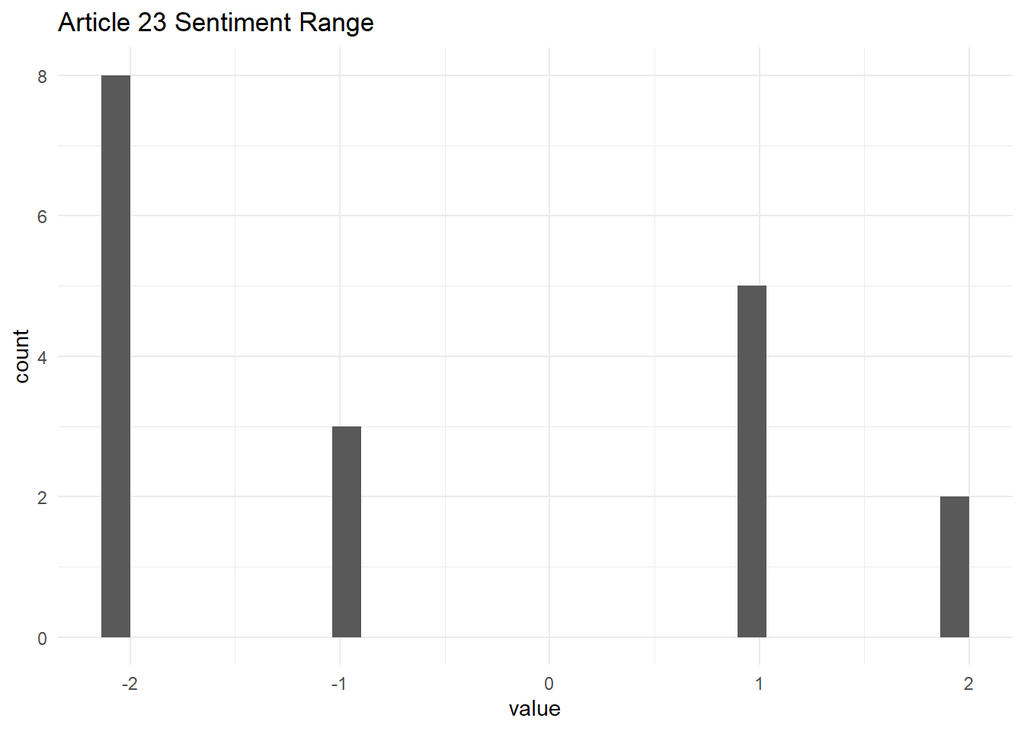

```r
#View(SEarticle23_affin)

ggplot(data = SEarticle23_affin,
       aes(x=value)
        )+
  geom_histogram()+
  ggtitle("Article 23 Sentiment Range")+
  theme_minimal()
```

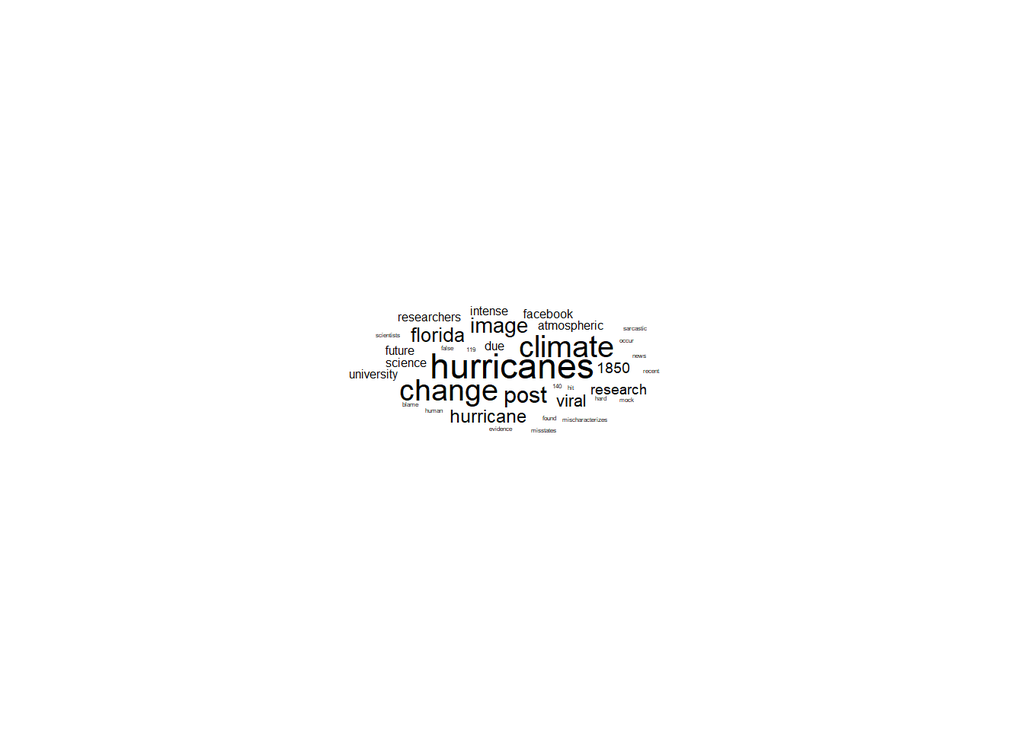

```r
#Could also do simple word clouds as we see
#below uses the ggwordcloud package

set.seed(42)
ggplot(SEarticle23[1:35,], aes(label = word, size = n)
       ) +
  geom_text_wordcloud() +
  theme_minimal()
```

## Article: Climate change inaction jeopardizes Energy Department facilities, says new report

Newspaper: Aiken Standard (South Carolina)

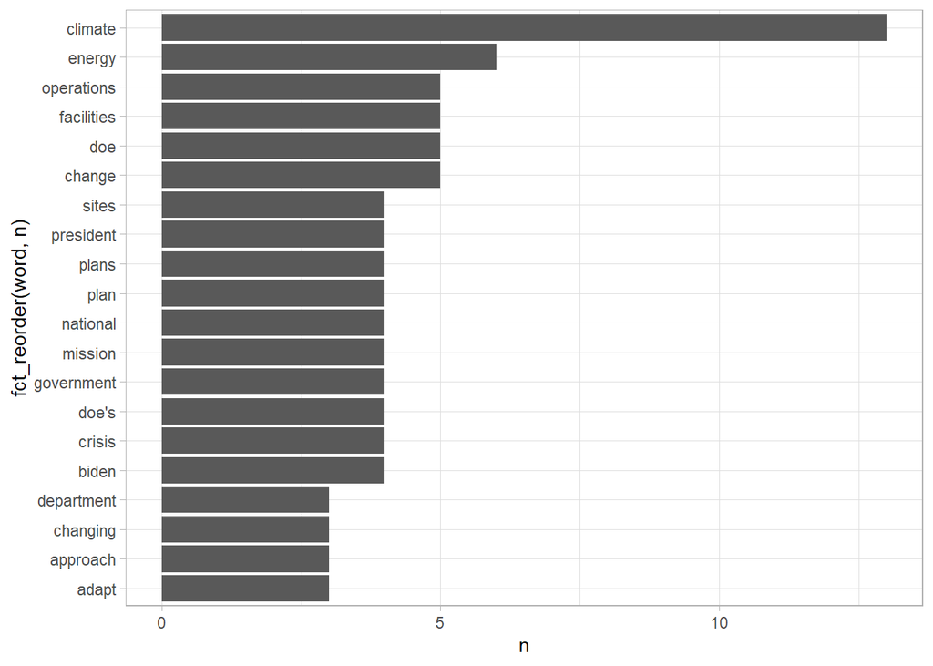

```r
SEarticle24 <- read_lines("07_text_mining/jeopardizes-Energy-Department.txt")

SEarticle24 <- tibble(SEarticle24)
#View(SEarticle24)

SEarticle24$SEarticle24 <- as.character(SEarticle24$SEarticle24)

SEarticle24 <- SEarticle24 %>%
  unnest_tokens(word, SEarticle24)%>%
  anti_join(stop_words)%>%
  count(word, sort=TRUE)
#View(SEarticle24)

ggplot(
  data = SEarticle24[1:20,],
  aes(x = fct_reorder(word,n),
      y = n)
  ) +
  geom_col() +
  coord_flip()+
  theme_light()
```

```r
#evaluating words for their connotation
SEarticle24_affin <- SEarticle24 %>%
  inner_join(get_sentiments("afinn"))#using a inner join to match words and add the sentiment variable
SEarticle24_nrc <- SEarticle24 %>%
  inner_join(get_sentiments("nrc"))
SEarticle24_bing <- SEarticle24 %>%
  inner_join(get_sentiments("bing"))
#We can just do some tabling to see the differences in bing and nrc, seems like Kennedy's speech at least first glanced was much more balanced in terms of negative/positive sentiment
table(SEarticle24_bing$sentiment) #much more positive
```

```
##
## negative positive
##       22        8
```

```r
table(SEarticle24_nrc$sentiment)
```

```
##
##        anger anticipation      disgust         fear          joy     negative
##           11            8            4           15            1           22
##     positive      sadness     surprise        trust
##           21            6            3           10
```

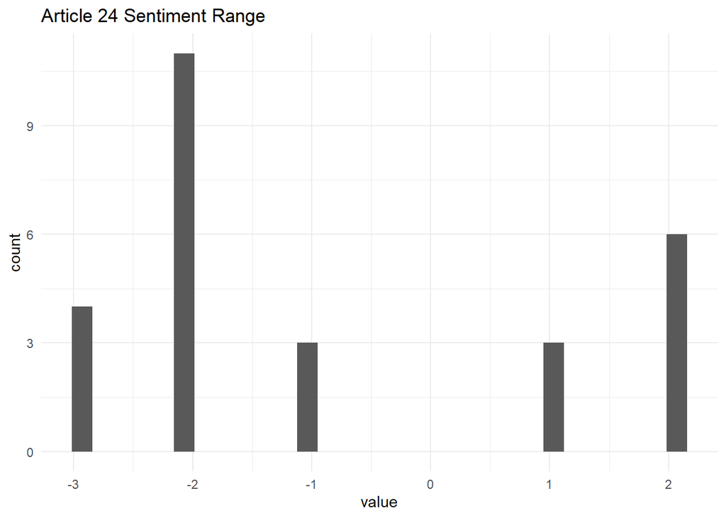

```r
#View(SEarticle24_affin)

ggplot(data = SEarticle24_affin,
       aes(x=value)
        )+
  geom_histogram()+
  ggtitle("Article 24 Sentiment Range")+
  theme_minimal()
```

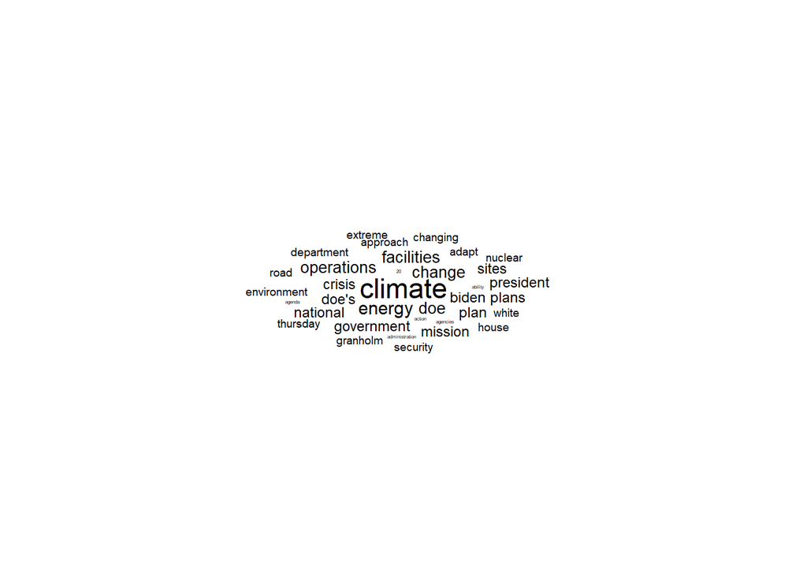

```r
#Could also do simple word clouds as we see
#below uses the ggwordcloud package

set.seed(42)
ggplot(SEarticle24[1:35,], aes(label = word, size = n)
       ) +
  geom_text_wordcloud() +
  theme_minimal()
```

## Article: Climate change is a national security threat and economic opportunity for Florida | Column; No American state has more to lose from inaction on climate change than Florida, writes a Florida congresswoman.

Newspaper: Tampa Bay Times

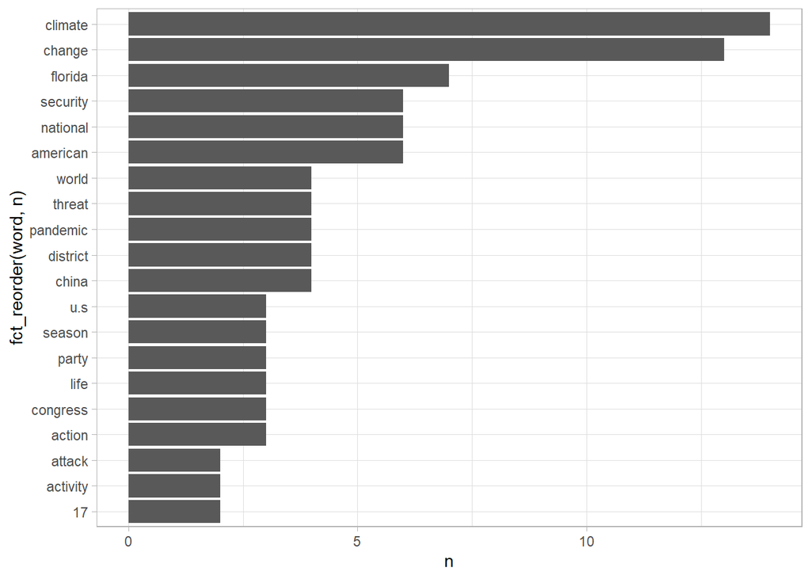

```r
SEarticle25 <- read_lines("07_text_mining/national security threat.txt")

SEarticle25 <- tibble(SEarticle25)
#View(SEarticle25)

SEarticle25$SEarticle25 <- as.character(SEarticle25$SEarticle25)

SEarticle25 <- SEarticle25 %>%
  unnest_tokens(word, SEarticle25)%>%
  anti_join(stop_words)%>%
  count(word, sort=TRUE)
#View(SEarticle25)

ggplot(
  data = SEarticle25[1:20,],
  aes(x = fct_reorder(word,n),
      y = n)
  ) +
  geom_col() +
  coord_flip()+
  theme_light()
```

```r
#evaluating words for their connotation
SEarticle25_affin <- SEarticle25 %>%
  inner_join(get_sentiments("afinn"))#using a inner join to match words and add the sentiment variable
SEarticle25_nrc <- SEarticle25 %>%
  inner_join(get_sentiments("nrc"))
SEarticle25_bing <- SEarticle25 %>%
  inner_join(get_sentiments("bing"))
#We can just do some tabling to see the differences in bing and nrc, seems like Kennedy's speech at least first glanced was much more balanced in terms of negative/positive sentiment
table(SEarticle25_bing$sentiment) #much more positive
```

```
##
## negative positive
##       25       13
```

```r
table(SEarticle25_nrc$sentiment)
```

```
##
##        anger anticipation      disgust         fear          joy     negative
##           13           13            6           22           10           29
##     positive      sadness     surprise        trust
##           35           12            5           20
```

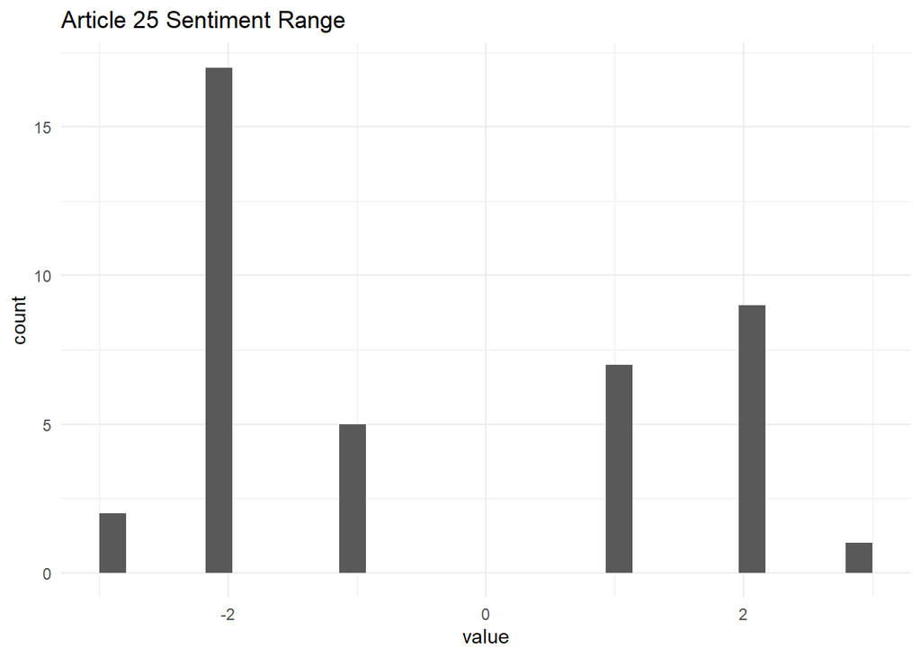

```r
#View(SEarticle25_affin)

ggplot(data = SEarticle25_affin,
       aes(x=value)
        )+
  geom_histogram()+
  ggtitle("Article 25 Sentiment Range")+
  theme_minimal()
```

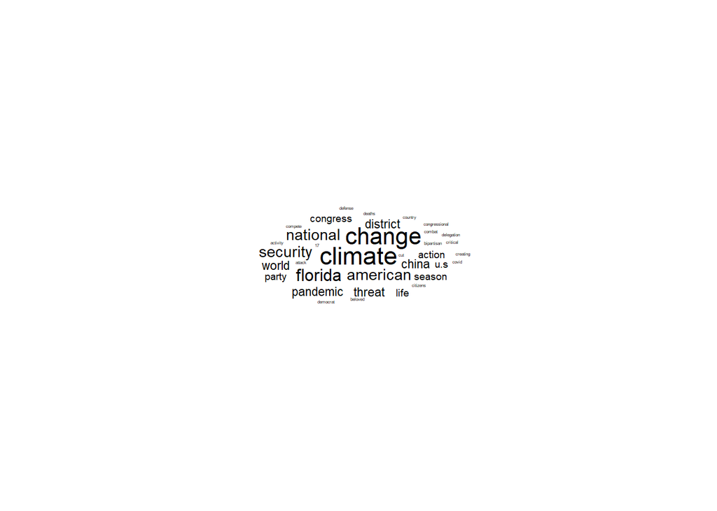

```r
#Could also do simple word clouds as we see
#below uses the ggwordcloud package

set.seed(42)
ggplot(SEarticle25[1:35,], aes(label = word, size = n)
       ) +
  geom_text_wordcloud() +
  theme_minimal()
```

## Article: Here’s how climate change could make future Red Tide blooms worse; From warm water to rainfall, there are many ways a changing climate could alter Florida’s blooms.

Newspaper: Tampa Bay Times

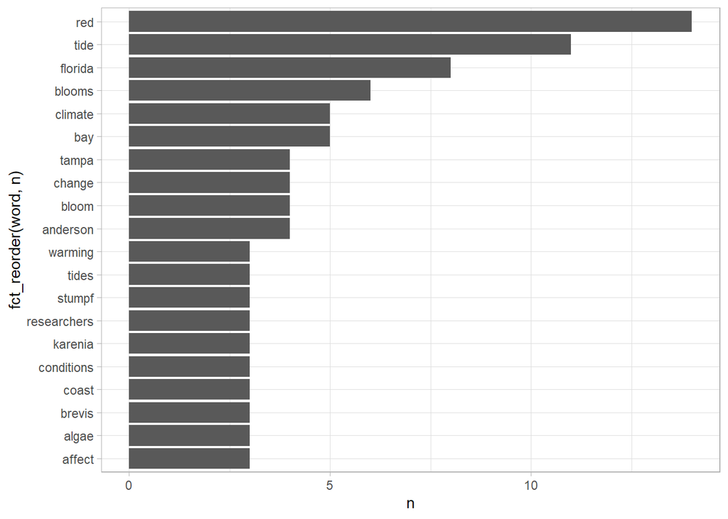

```r
SEarticle26 <- read_lines("07_text_mining/Red Tide.txt")

SEarticle26 <- tibble(SEarticle26)
#View(SEarticle26)

SEarticle26$SEarticle26 <- as.character(SEarticle26$SEarticle26)

SEarticle26 <- SEarticle26 %>%
  unnest_tokens(word, SEarticle26)%>%
  anti_join(stop_words)%>%
  count(word, sort=TRUE)
#View(SEarticle26)

ggplot(
  data = SEarticle26[1:20,],
  aes(x = fct_reorder(word,n),
      y = n)
  ) +
  geom_col() +
  coord_flip()+
  theme_light()
```

```r
#evaluating words for their connotation
SEarticle26_affin <- SEarticle26 %>%
  inner_join(get_sentiments("afinn"))#using a inner join to match words and add the sentiment variable
SEarticle26_nrc <- SEarticle26 %>%
  inner_join(get_sentiments("nrc"))
SEarticle26_bing <- SEarticle26 %>%
  inner_join(get_sentiments("bing"))
#We can just do some tabling to see the differences in bing and nrc, seems like Kennedy's speech at least first glanced was much more balanced in terms of negative/positive sentiment
table(SEarticle26_bing$sentiment) #much more positive
```

```
##
## negative positive
##       20        6
```

```r
table(SEarticle26_nrc$sentiment)
```

```
##
##        anger anticipation      disgust         fear          joy     negative
##            9           12            7           11            9           19
##     positive      sadness     surprise        trust
##           29            9            3           21
```

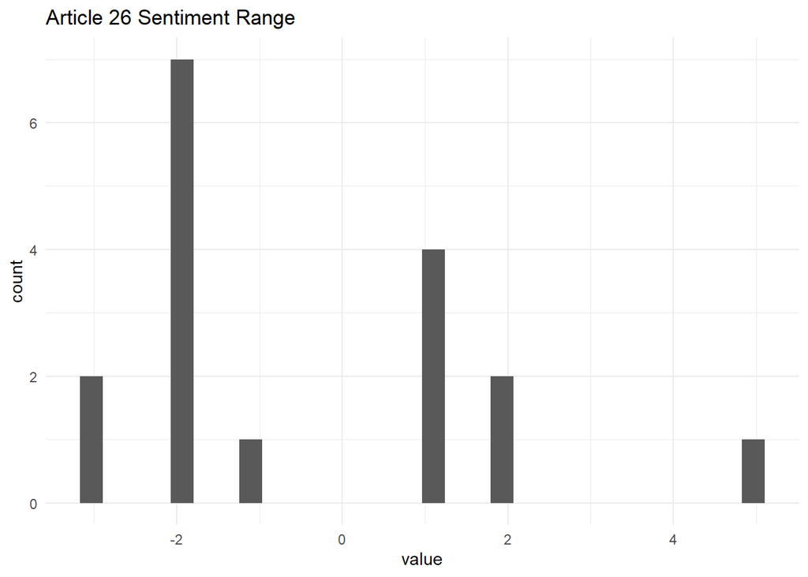

```r
#View(SEarticle26_affin)

ggplot(data = SEarticle26_affin,
       aes(x=value)
        )+
  geom_histogram()+
  ggtitle("Article 26 Sentiment Range")+
  theme_minimal()
```

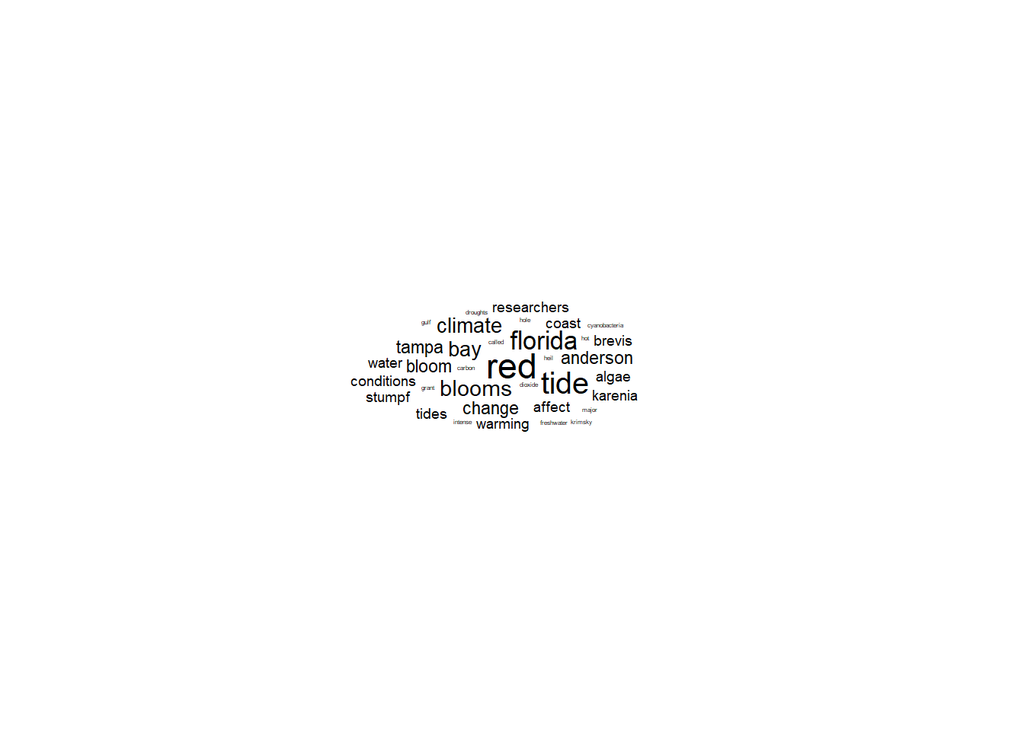

```r
#Could also do simple word clouds as we see
#below uses the ggwordcloud package

set.seed(42)
ggplot(SEarticle26[1:35,], aes(label = word, size = n)
       ) +
  geom_text_wordcloud() +
  theme_minimal()
```

## Article: Reducing Racism and Global Climate Change in One Step

Newspaper: American Institute for Economic Research

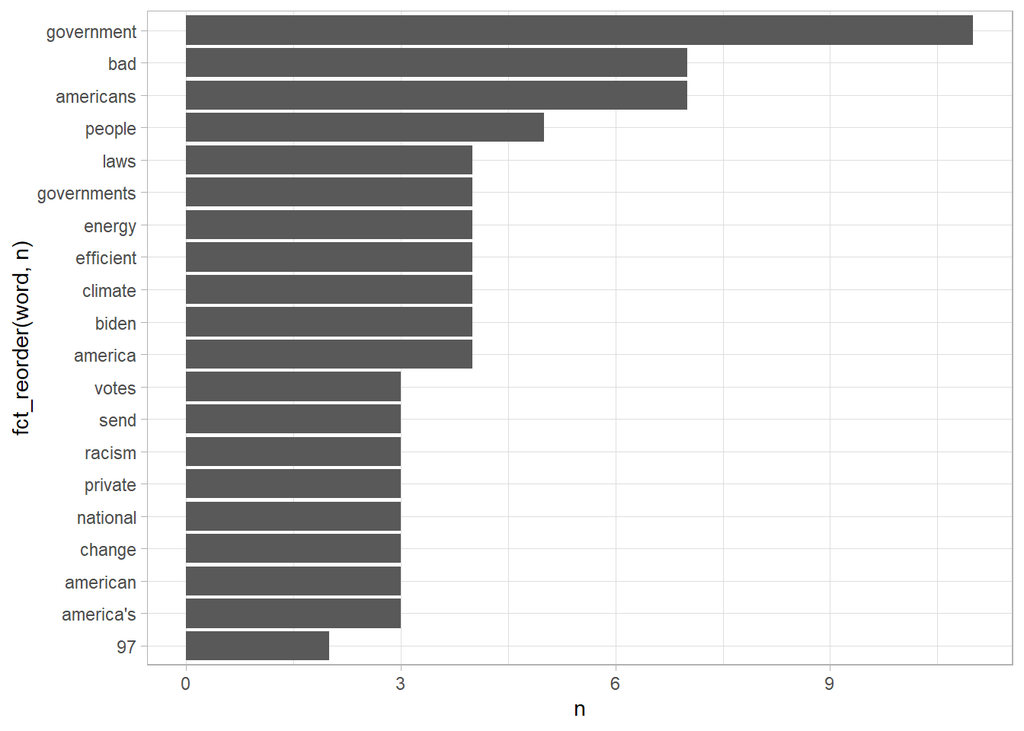

```r
SEarticle27 <- read_lines("07_text_mining/Reducing Racism.txt")

SEarticle27 <- tibble(SEarticle27)
#View(SEarticle27)

SEarticle27$SEarticle27 <- as.character(SEarticle27$SEarticle27)

SEarticle27 <- SEarticle27 %>%
  unnest_tokens(word, SEarticle27)%>%
  anti_join(stop_words)%>%
  count(word, sort=TRUE)
#View(SEarticle27)

ggplot(
  data = SEarticle27[1:20,],
  aes(x = fct_reorder(word,n),
      y = n)
  ) +
  geom_col() +
  coord_flip()+
  theme_light()
```

```r
#evaluating words for their connotation
SEarticle27_affin <- SEarticle27 %>%
  inner_join(get_sentiments("afinn"))#using a inner join to match words and add the sentiment variable
SEarticle27_nrc <- SEarticle27 %>%
  inner_join(get_sentiments("nrc"))
SEarticle27_bing <- SEarticle27 %>%
  inner_join(get_sentiments("bing"))
#We can just do some tabling to see the differences in bing and nrc, seems like Kennedy's speech at least first glanced was much more balanced in terms of negative/positive sentiment
table(SEarticle27_bing$sentiment) #much more positive
```

```
##
## negative positive
##       34       21
```

```r
table(SEarticle27_nrc$sentiment)
```

```
##
##        anger anticipation      disgust         fear          joy     negative
##            9           11            8           17           15           26
##     positive      sadness     surprise        trust
##           45           12            6           27
```

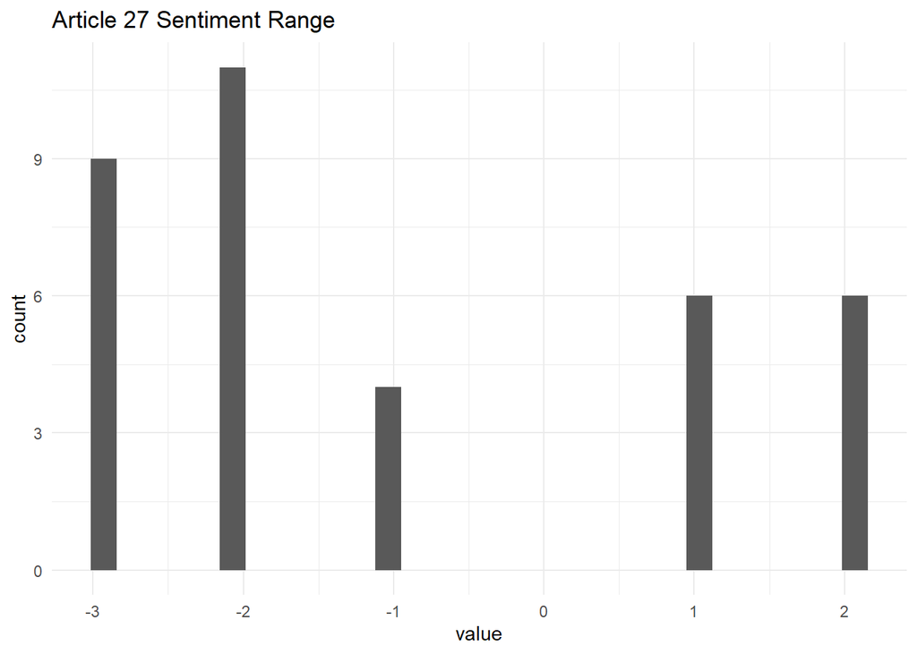

```r
#View(SEarticle27_affin)

ggplot(data = SEarticle27_affin,
       aes(x=value)
        )+
  geom_histogram()+
  ggtitle("Article 27 Sentiment Range")+
  theme_minimal()
```

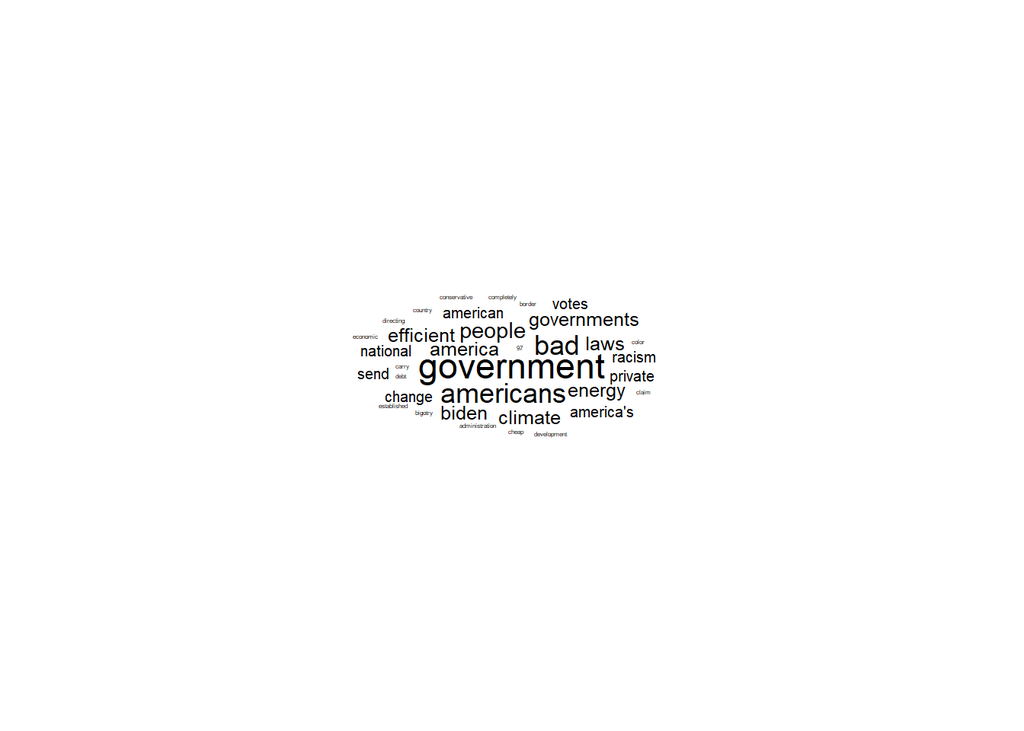

```r
#Could also do simple word clouds as we see
#below uses the ggwordcloud package

set.seed(42)
ggplot(SEarticle27[1:35,], aes(label = word, size = n)
       ) +
  geom_text_wordcloud() +
  theme_minimal()
```

## Article: Study: Northwest heat wave impossible without climate change; An international team of 27 scientists calculated that climate change increased chances of the extreme heat occurring by at least 150 times, but likely much more.

Newspaper: Tampa Bay Times

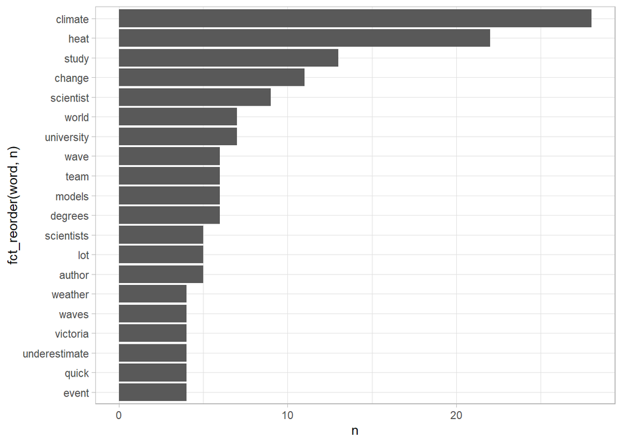

```r
SEarticle28 <- read_lines("07_text_mining/Study_ Northwest.txt")

SEarticle28 <- tibble(SEarticle28)
#View(SEarticle28)

SEarticle28$SEarticle28 <- as.character(SEarticle28$SEarticle28)

SEarticle28 <- SEarticle28 %>%
  unnest_tokens(word, SEarticle28)%>%
  anti_join(stop_words)%>%
  count(word, sort=TRUE)
#View(SEarticle28)

ggplot(
  data = SEarticle28[1:20,],
  aes(x = fct_reorder(word,n),
      y = n)
  ) +
  geom_col() +
  coord_flip()+
  theme_light()
```

```r
#evaluating words for their connotation
SEarticle28_affin <- SEarticle28 %>%
  inner_join(get_sentiments("afinn"))#using a inner join to match words and add the sentiment variable
SEarticle28_nrc <- SEarticle28 %>%
  inner_join(get_sentiments("nrc"))
SEarticle28_bing <- SEarticle28 %>%
  inner_join(get_sentiments("bing"))
#We can just do some tabling to see the differences in bing and nrc, seems like Kennedy's speech at least first glanced was much more balanced in terms of negative/positive sentiment
table(SEarticle28_bing$sentiment) #much more positive
```

```
##
## negative positive
##       16        3
```

```r
table(SEarticle28_nrc$sentiment)
```

```
##
##        anger anticipation      disgust         fear          joy     negative
##            8            8            6            8            3           14
##     positive      sadness     surprise        trust
##           21            7            7           17
```

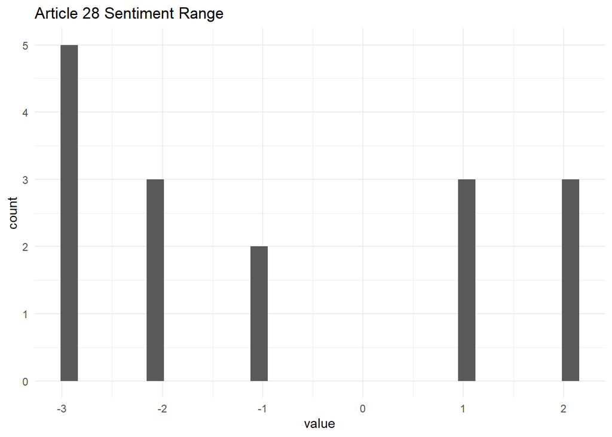

```r
#View(SEarticle28_affin)

ggplot(data = SEarticle28_affin,
       aes(x=value)
        )+
  geom_histogram()+
  ggtitle("Article 28 Sentiment Range")+
  theme_minimal()
```

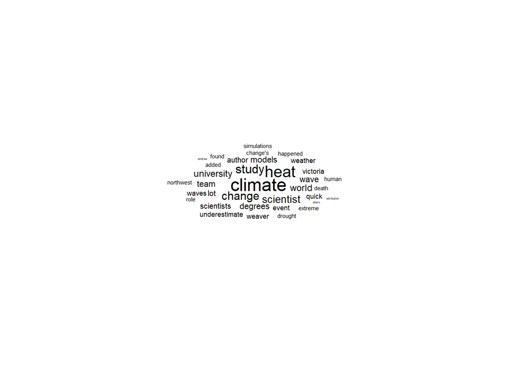

```r
#Could also do simple word clouds as we see
#below uses the ggwordcloud package

set.seed(42)
ggplot(SEarticle28[1:35,], aes(label = word, size = n)
       ) +
  geom_text_wordcloud() +
  theme_minimal()
```